# Appendix B

Study 2 - Attention Bias Manipulation

MM

2026-09-17

# Data Preparation

This section documents the main preprocessing steps used to derive the variables analyzed in Study 2. Consistent with the manuscript, data preparation for perfectionism and attentional measures followed the same procedures as in Study 1. This section therefore focuses on the Study 2-specific extensions, namely repeated mood assessments and pre–post attentional data.

## Questionnaire data

Perfectionism was assessed using the Hewitt and Flett Multidimensional Perfectionism Scale (HMPS) and the Frost Multidimensional Perfectionism Scale (FMPS). As in Study 1, item scoring, reverse coding, and computation of questionnaire totals followed the standard scoring procedures for each instrument.

Momentary positive and negative mood/emotional states were assessed repeatedly using seven Visual Analog Mood Scales (VAMS; 0–9). In line with the manuscript, these items were aggregated into Positive Mood (happy, excited, positive mood) and Negative Mood (sad, anxious, angry, negative mood) scores. Baseline depressive and anxiety symptoms were assessed using the CES-D and GAD-7 and were retained as baseline symptom control variables, not as focal outcomes.

```r
# HMPS reverse coding
qu2[, c("HMPS_2", "HMPS_3", "HMPS_4", "HMPS_8", "HMPS_9", "HMPS_10", "HMPS_12",
        "HMPS_19", "HMPS_21", "HMPS_24", "HMPS_30", "HMPS_34", "HMPS_36", "HMPS_37",
        "HMPS_38", "HMPS_43", "HMPS_44", "HMPS_45")] <-
  8 - qu2[, c("HMPS_2", "HMPS_3", "HMPS_4", "HMPS_8", "HMPS_9", "HMPS_10", "HMPS_12",
              "HMPS_19", "HMPS_21", "HMPS_24", "HMPS_30", "HMPS_34", "HMPS_36", "HMPS_37",
              "HMPS_38", "HMPS_43", "HMPS_44", "HMPS_45")]

# HMPS subscales
SOP <- qu2[, c("HMPS_1", "HMPS_6", "HMPS_8", "HMPS_12", "HMPS_14", "HMPS_15", "HMPS_17",
               "HMPS_20", "HMPS_23", "HMPS_28", "HMPS_32", "HMPS_34", "HMPS_36", "HMPS_40", "HMPS_42")]
OOP <- qu2[, c("HMPS_2", "HMPS_3", "HMPS_4", "HMPS_7", "HMPS_10", "HMPS_16", "HMPS_19",
               "HMPS_22", "HMPS_24", "HMPS_26", "HMPS_27", "HMPS_29", "HMPS_38", "HMPS_43", "HMPS_45")]
SPP <- qu2[, c("HMPS_5", "HMPS_9", "HMPS_11", "HMPS_13", "HMPS_18", "HMPS_21", "HMPS_25",
               "HMPS_30", "HMPS_31", "HMPS_33", "HMPS_35", "HMPS_37", "HMPS_39", "HMPS_41", "HMPS_44")]

qu2$SOP <- rowSums(SOP)
qu2$OOP <- rowSums(OOP)
qu2$SPP <- rowSums(SPP)

# FMPS subscales
PS <- qu2[, c("FMPS_4", "FMPS_6", "FMPS_12", "FMPS_16", "FMPS_19", "FMPS_24", "FMPS_30")]
PE <- qu2[, c("FMPS_1", "FMPS_11", "FMPS_15", "FMPS_20", "FMPS_26")]
PC <- qu2[, c("FMPS_3", "FMPS_5", "FMPS_22", "FMPS_35")]
CM <- qu2[, c("FMPS_9", "FMPS_10", "FMPS_13", "FMPS_14", "FMPS_18", "FMPS_21", "FMPS_23", "FMPS_25", "FMPS_34")]
DA <- qu2[, c("FMPS_17", "FMPS_28", "FMPS_32", "FMPS_33")]
O  <- qu2[, c("FMPS_2", "FMPS_7", "FMPS_8", "FMPS_27", "FMPS_29", "FMPS_31")]

qu2$PS <- rowSums(PS)
qu2$PE <- rowSums(PE)
qu2$PC <- rowSums(PC)
qu2$CM <- rowSums(CM)
qu2$DA <- rowSums(DA)
qu2$O  <- rowSums(O)

# VAMS composites
POS_1 <- qu2[, c("VAMS1_1", "VAMS1_6", "VAMS1_7")]
NEG_1 <- qu2[, c("VAMS1_2", "VAMS1_3", "VAMS1_4", "VAMS1_5")]
POS_2 <- qu2[, c("VAMS2_1", "VAMS2_6", "VAMS2_7")]
NEG_2 <- qu2[, c("VAMS2_2", "VAMS2_3", "VAMS2_4", "VAMS2_5")]
POS_3 <- qu2[, c("VAMS3_1", "VAMS3_6", "VAMS3_7")]
NEG_3 <- qu2[, c("VAMS3_2", "VAMS3_3", "VAMS3_4", "VAMS3_5")]
POS_4 <- qu2[, c("VAMS4_1", "VAMS4_6", "VAMS4_7")]
NEG_4 <- qu2[, c("VAMS4_2", "VAMS4_3", "VAMS4_4", "VAMS4_5")]

qu2$POS_1 <- rowSums(POS_1)
qu2$NEG_1 <- rowSums(NEG_1)
qu2$POS_2 <- rowSums(POS_2)
qu2$NEG_2 <- rowSums(NEG_2)
qu2$POS_3 <- rowSums(POS_3)
qu2$NEG_3 <- rowSums(NEG_3)
qu2$POS_4 <- rowSums(POS_4)
qu2$NEG_4 <- rowSums(NEG_4)

# CES-D reverse coding and totals
qu2[, c("CESD_4", "CESD_8", "CESD_12", "CESD_16")] <-
  3 - qu2[, c("CESD_4", "CESD_8", "CESD_12", "CESD_16")]

CESD <- qu2[, c("CESD_1", "CESD_2", "CESD_3", "CESD_4", "CESD_5", "CESD_6", "CESD_7", "CESD_8",
                "CESD_9", "CESD_10", "CESD_11", "CESD_12", "CESD_13", "CESD_14", "CESD_15",
                "CESD_16", "CESD_17", "CESD_18", "CESD_19", "CESD_20")]
qu2$CESD <- rowSums(CESD)

# GAD-7 totals
qu2$GAD7_1 <- as.numeric(qu2$GAD7_1)
qu2$GAD7_2 <- as.numeric(qu2$GAD7_2)
qu2$GAD7_3 <- as.numeric(qu2$GAD7_3)
qu2$GAD7_4 <- as.numeric(qu2$GAD7_4)
qu2$GAD7_5 <- as.numeric(qu2$GAD7_5)
qu2$GAD7_6 <- as.numeric(qu2$GAD7_6)
qu2$GAD7_7 <- as.numeric(qu2$GAD7_7)

GAD7 <- qu2[, c("GAD7_1", "GAD7_2", "GAD7_3", "GAD7_4", "GAD7_5", "GAD7_6", "GAD7_7")]
qu2$GAD7 <- rowSums(GAD7)
```

### Outlier Handling

Outliers were identified before computing descriptive statistics and correlations. Following the same procedure as in Study 1, univariate outliers were defined as observations with standardized scores below -3 or above +3, and multivariate outliers were assessed using Mahalanobis distance.

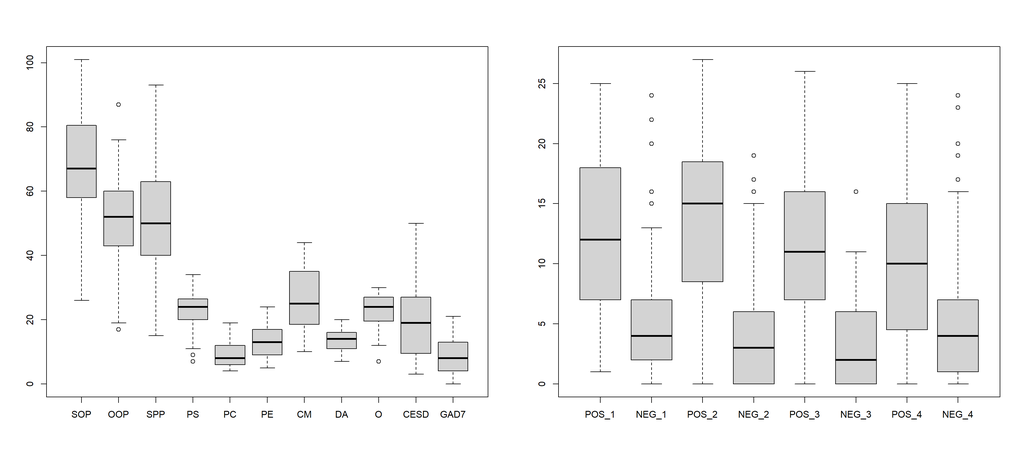

```r
par(mfrow=c(1,2))
boxplot(qu2[, c("SOP", "OOP","SPP", "PS", "PC", "PE", "CM", "DA", "O", "CESD", "GAD7")])
boxplot(qu2[, c("POS_1", "NEG_1", "POS_2", "NEG_2","POS_3", "NEG_3", "POS_4", "NEG_4")])
```

```r
# Standardize questionnaire variables
qu2[, c("ZSOP", "ZOOP", "ZSPP", "ZPS", "ZPC", "ZPE", "ZCM", "ZDA", "ZO", "ZGAD7", "ZCESD",
        "ZPOS_1", "ZNEG_1", "ZPOS_2", "ZNEG_2", "ZPOS_3", "ZNEG_3", "ZPOS_4", "ZNEG_4")] <-
  scale(qu2[, c("SOP", "OOP", "SPP", "PS", "PC", "PE", "CM", "DA", "O", "GAD7", "CESD",
                "POS_1", "NEG_1", "POS_2", "NEG_2", "POS_3", "NEG_3", "POS_4", "NEG_4")])

# Identify univariate outliers
univar_out <- c(
  which(qu2$ZSOP > 3 | qu2$ZSOP < -3),
  which(qu2$ZOOP > 3 | qu2$ZOOP < -3),
  which(qu2$ZSPP > 3 | qu2$ZSPP < -3),
  which(qu2$ZPS > 3 | qu2$ZPS < -3),
  which(qu2$ZPE > 3 | qu2$ZPE < -3),
  which(qu2$ZPC > 3 | qu2$ZPC < -3),
  which(qu2$ZCM > 3 | qu2$ZCM < -3),
  which(qu2$ZDA > 3 | qu2$ZDA < -3),
  which(qu2$ZO > 3 | qu2$ZO < -3),
  which(qu2$ZGAD7 > 3 | qu2$ZGAD7 < -3),
  which(qu2$ZCESD > 3 | qu2$ZCESD < -3),
  which(qu2$ZPOS_1 > 3 | qu2$ZPOS_1 < -3),
  which(qu2$ZNEG_1 > 3 | qu2$ZNEG_1 < -3),
  which(qu2$ZPOS_2 > 3 | qu2$ZPOS_2 < -3),
  which(qu2$ZNEG_2 > 3 | qu2$ZNEG_2 < -3),
  which(qu2$ZPOS_3 > 3 | qu2$ZPOS_3 < -3),
  which(qu2$ZNEG_3 > 3 | qu2$ZNEG_3 < -3),
  which(qu2$ZPOS_4 > 3 | qu2$ZPOS_4 < -3),
  which(qu2$ZNEG_4 > 3 | qu2$ZNEG_4 < -3)
)

univar_out <- unique(univar_out)

# Remove univariate outliers
qu2 <- qu2[-univar_out, ]

# Identify multivariate outliers
vars <- qu2[, c("SOP", "OOP", "SPP", "PS", "PC", "PE", "CM", "DA", "O",
                "POS_1", "NEG_1", "POS_2", "NEG_2", "POS_3", "NEG_3", "POS_4", "NEG_4")]
md <- mahalanobis(vars, center = colMeans(vars), cov = cov(vars))
cutoff <- qchisq(p = 1 - .001, df = ncol(vars))
multivar_out_MH <- which(md > cutoff)

length(multivar_out_MH)
```

```
## [1] 0
```

```r
# Remove one participant flagged administratively as outlier in the condition variable
which(qu2$Condition == "Outlier")
```

```
## [1] 54
```

```r
qu2 <- qu2[-which(qu2$Condition == "Outlier"), ]
```

Univariate outliers were excluded from subsequent analyses. No multivariate outliers were identified.

### Perfectionism Dimensions

Following the same procedure as in Study 1, Perfectionistic Strivings was computed as the sum of standardized Personal Standards (FMPS-PS) and Self-Oriented Perfectionism (HMPS-SOP) scores. Perfectionistic Concerns was computed as the sum of standardized Concerns over Mistakes (FMPS-CM), Doubts about Actions (FMPS-DA), and Socially Prescribed Perfectionism (HMPS-SPP) scores.

```r
qu2$Perf_Strivings <- rowSums(qu2[, c("ZPS", "ZSOP")])
qu2$Perf_Concerns  <- rowSums(qu2[, c("ZCM", "ZDA", "ZSPP")])
```

### Mood Outcomes

Positive and negative emotion scores were computed as sums of the corresponding VAMS items at each assessment. The primary analyses operationalized emotional reactivity using post-assessment mood conditional on the corresponding score at the immediately preceding assessment: post-ABM mood was adjusted for pre-ABM mood, and post-Tangram mood was adjusted for mood immediately before the Tangram task.

Questionnaire descriptives and correlations are calculated below after identifying the common attention-task analytic sample.

## Attention Bias Measurement

Attentional data were collected at two time points, before (t1) and after (t2) the ABM procedure. As in Study 1, attention bias was assessed using the FV-FICB task with word stimuli from five semantic categories: Success, Failure, Positive, Negative, and Neutral.

### Response Times

Response times were defined as the latency between onset of the changed display and the participant’s response. Trial presentation order was retained as `trial_nr`; the ordering of the RT rows was verified against `TRIAL_INDEX` in the raw eye-tracking records. Analyses were conducted on correct trials only, and trials with response times below 200 ms were excluded.

### Correct Responses

Correct responses were recorded when participants accurately identified the changed word.

```r
rt2$correct_response <- as.factor(rt2$correct_response) %>%
  dplyr::recode("Vrai" = 1, "Faux" = 0)

correct_responses <- rt2[,c("subject_id", "correct_response", "Temps_de_mesure")] %>% group_by(subject_id, Temps_de_mesure) %>% summarize(correct_response = sum(correct_response))

incorrect <- which(rt2$correct_response == 0)
rt200 <- which(rt2$response_time < 200)

length(incorrect)
```

```
## [1] 221
```

```r
length(rt200)
```

```
## [1] 24
```

```r
rt2$response_time[c(incorrect, rt200)] <- NA
```

Rule awareness was assessed at the end of each block and coded as a binary variable (0 = no, 1 = yes). This variable was used to model dispersion in subsequent manipulation check analyses.

```r
 rt2 <- rt2 %>% rename(guessed_block_rule = response_keyboard_response)
rt2$guessed_block_rule <- as.factor(rt2$guessed_block_rule) %>%
  dplyr::recode("o" = 1, "O" = 1, "n" = 0, "N" = 0)
```

For manipulation checks, response-time data were reshaped to a paired T1-T2 format so that post-ABM outcomes could be modeled conditional on their corresponding pre-ABM values.

```r
 t1 <- which(rt2$Temps_de_mesure == "T1")
t2 <- which(rt2$Temps_de_mesure == "T2")

rt2_1 <- rt2[t1, ]
rt2_2 <- rt2[t2, ]

drop <- c("Temps_de_mesure", "ID", "datetime", "response_position", "participant_response", "correct_response")

rt2_1 <- rt2_1[, !(names(rt2_1) %in% drop)] %>%
  rename(subject_id_1 = subject_id,
         block_nr_1 = block_nr,
         trial_nr_1 = trial_nr,
         response_time_1 = response_time,
         guessed_block_rule_1 = guessed_block_rule)

rt2_2 <- rt2_2[, !(names(rt2_2) %in% drop)] %>%
  rename(subject_id_2 = subject_id,
         block_nr_2 = block_nr,
         trial_nr_2 = trial_nr,
         response_time_2 = response_time,
         guessed_block_rule_2 = guessed_block_rule)

rt <- rt2_1 %>%
  inner_join(
    rt2_2,
    by = c("Code", "Change_category", "Change_location", "Change_word", "Flicker_word",
           "A", "B", "C", "D", "E",
           "OS_A_word", "OS_B_word", "OS_C_word", "OS_D_word", "OS_E_word",
           "CS_A_word", "CS_B_word", "CS_C_word", "CS_D_word", "CS_E_word", "block_id"),
    relationship = "one-to-one"
  )

message("Paired RT participants: ", n_distinct(rt$Code), " of ",
        n_distinct(intersect(rt2_1$Code, rt2_2$Code)),
        " participants represented at both assessments.")
```

### Eye Tracking

Eye movements during the free-viewing phase were used to compute the attentional indices. As in Study 1, raw eye-tracking data were recoded prior to index construction, and indices were aggregated at the block level.

As in Study 1, the following block-level indices were derived: probability of first or second fixation, latency to first fixation, and dwell time. Dwell time was computed for the whole trial and separately for the early, intermediate, and late viewing phases.

```r
# Merge ET with RT to recover block-level rule variables. EyeLink TRIAL_INDEX
# corresponds to trial_nr within each participant and measurement occasion.
rt_block_lookup2 <- rt2 %>%
  select(Temps_de_mesure, subject_id, trial_nr, Change_category, Code,
         block_id, block_nr, guessed_block_rule) %>%
  distinct()

etrt2 <- et2 %>%
  rename(trial_nr = TRIAL_INDEX) %>%
  left_join(rt_block_lookup2,
            by = c("MEASUREMENT_TIME" = "Temps_de_mesure", "subject_id",
                   "trial_nr", "Change_category"),
            relationship = "many-to-one") %>%
  rename(Temps_de_mesure = MEASUREMENT_TIME)

et2a <- etrt2[c("Temps_de_mesure", "Code", "subject_id", "block_id", "block_nr", "IA_LABEL", "Change_category", "guessed_block_rule",
                "IA_DWELL_TIME", "IA_DWELL_TIME_500to1500", "IA_DWELL_TIME_1500to3500", "IA_DWELL_TIME_3500to5500",
                "IA_FIRST_FIXATION_VISITED_IA_COUNT", "IA_FIRST_FIXATION_TIME")] %>%
  group_by(Temps_de_mesure, Code, subject_id, block_id, block_nr, IA_LABEL, Change_category, guessed_block_rule) %>%
  reframe(
    IA_FIRST_FIXATION_PROBABILITY = mean(na.omit(IA_FIRST_FIXATION_VISITED_IA_COUNT)),
    IA_FIRST_FIXATION_TIME_BLOCKMEAN = mean(na.omit(IA_FIRST_FIXATION_TIME)),
    IA_DWELL_TIME_BLOCKMEAN = mean(IA_DWELL_TIME),
    IA_DWELL_TIME_500to1500_BLOCKMEAN = mean(IA_DWELL_TIME_500to1500),
    IA_DWELL_TIME_1500to3500_BLOCKMEAN = mean(IA_DWELL_TIME_1500to3500),
    IA_DWELL_TIME_3500to5500_BLOCKMEAN = mean(IA_DWELL_TIME_3500to5500)
  )

et2b <- et2a %>%
  group_by(Temps_de_mesure, subject_id, block_id, block_nr) %>%
  summarise(
    AVG_FIRST_FIXATION_TIME = sum(na.omit(IA_FIRST_FIXATION_TIME_BLOCKMEAN)),
    AVG_DWELL_TIME = sum(IA_DWELL_TIME_BLOCKMEAN),
    AVG_DWELL_TIME_500to1500 = sum(IA_DWELL_TIME_500to1500_BLOCKMEAN),
    AVG_DWELL_TIME_1500to3500 = sum(IA_DWELL_TIME_1500to3500_BLOCKMEAN),
    AVG_DWELL_TIME_3500to5500 = sum(IA_DWELL_TIME_3500to5500_BLOCKMEAN)
  )

et2 <- et2a %>% inner_join(et2b, relationship = "many-to-many")

et2$first_fix_prob <- et2$IA_FIRST_FIXATION_PROBABILITY
et2$first_fix_latency <- et2$IA_FIRST_FIXATION_TIME_BLOCKMEAN / et2$AVG_FIRST_FIXATION_TIME
et2$dwell_time <- et2$IA_DWELL_TIME_BLOCKMEAN / et2$AVG_DWELL_TIME
et2$dwell_time_early <- et2$IA_DWELL_TIME_500to1500_BLOCKMEAN / et2$AVG_DWELL_TIME_500to1500
et2$dwell_time_intermediate <- et2$IA_DWELL_TIME_1500to3500_BLOCKMEAN / et2$AVG_DWELL_TIME_1500to3500
et2$dwell_time_late <- et2$IA_DWELL_TIME_3500to5500_BLOCKMEAN / et2$AVG_DWELL_TIME_3500to5500
```

```r
# Remove remaining missing values
missing_ffp2 <- which(is.na(et2$first_fix_prob))
missing_ffl2 <- which(is.na(et2$first_fix_latency))
missing_dte2 <- which(is.na(et2$dwell_time_early))
missing_dtl2 <- which(is.na(et2$dwell_time_late))

et2 <- et2[-unique(c(missing_ffp2, missing_ffl2, missing_dte2, missing_dtl2)), ]
```

For manipulation checks, eye-tracking data were reshaped to paired T1-T2 format so that post-ABM outcomes could be modeled conditional on their corresponding pre-ABM values.

```r
t1 <- which(et2$Temps_de_mesure == "T1")
t2 <- which(et2$Temps_de_mesure == "T2")

et2_1 <- et2[t1, ]
et2_2 <- et2[t2, ]

et2_1 <- et2_1[c("Code", "subject_id", "block_id", "block_nr", "IA_LABEL", "Change_category",
                 "guessed_block_rule", "first_fix_prob", "first_fix_latency", "dwell_time",
                 "dwell_time_early", "dwell_time_intermediate", "dwell_time_late")] %>%
  rename(subject_id_1 = subject_id,
         block_nr_1 = block_nr,
         first_fix_prob_1 = first_fix_prob,
         first_fix_latency_1 = first_fix_latency,
         dwell_time_1 = dwell_time,
         dwell_time_early_1 = dwell_time_early,
         dwell_time_intermediate_1 = dwell_time_intermediate,
         dwell_time_late_1 = dwell_time_late,
         guessed_block_rule_1 = guessed_block_rule)

et2_2 <- et2_2[c("Code", "subject_id", "block_id", "block_nr", "IA_LABEL", "Change_category",
                 "guessed_block_rule", "first_fix_prob", "first_fix_latency", "dwell_time",
                 "dwell_time_early", "dwell_time_intermediate", "dwell_time_late")] %>%
  rename(subject_id_2 = subject_id,
         block_nr_2 = block_nr,
         first_fix_prob_2 = first_fix_prob,
         first_fix_latency_2 = first_fix_latency,
         dwell_time_2 = dwell_time,
         dwell_time_early_2 = dwell_time_early,
         dwell_time_intermediate_2 = dwell_time_intermediate,
         dwell_time_late_2 = dwell_time_late,
         guessed_block_rule_2 = guessed_block_rule)

et <- et2_1 %>%
  inner_join(
    et2_2,
    by = c("Code", "block_id", "IA_LABEL", "Change_category"),
    relationship = "one-to-one"
  )

message("Paired eye-tracking participants: ", n_distinct(et$Code), " of ",
        n_distinct(intersect(et2_1$Code, et2_2$Code)),
        " participants represented at both assessments.")
```

## Descriptive Statistics

All Study 2 analyses were restricted to participants represented in both the paired response-time and paired eye-tracking datasets. Questionnaire variables were retained at one row per participant, preventing repeated task observations from weighting the participant-level descriptives or mood analyses.

```r
task_completer_ids <- inner_join(
  rt %>% distinct(ID = Code),
  et %>% distinct(ID = Code),
  by = "ID",
  relationship = "one-to-one"
)

qu2 <- qu2 %>%
  semi_join(task_completer_ids, by = "ID") %>%
  distinct(ID, .keep_all = TRUE)

stopifnot(nrow(qu2) == n_distinct(qu2$ID))
message("Study 2 common task-completer sample: N = ", nrow(qu2))

# Apply the same participant restriction to task-level objects created above.
rt2 <- rt2 %>% filter(Code %in% qu2$ID)
rt_qu2 <- rt_qu2 %>% semi_join(qu2 %>% distinct(ID), by = "ID")
correct_responses <- correct_responses %>%
  semi_join(rt2 %>% distinct(subject_id), by = "subject_id")
```

**Sample Demographics**

```r
round(psych::describe(qu2$Age), 2)
```

```
##    vars  n  mean   sd median trimmed  mad min max range skew kurtosis   se
## X1    1 92 22.11 5.37     21   21.08 2.97  18  56    38 3.27    15.68 0.56
```

```r
table(qu2$Sexe, useNA = "ifany")
```

```
##
## Femme\r\n Homme\r\n
##        72        20
```

```r
table(qu2$Genre, useNA = "ifany")
```

```
##
## <NA>
##   92
```

```r
table(qu2$Actual_Studies, useNA = "ifany")
```

```
##
##       BAC I      BAC II     BAC III      BAC IV    Doctorat    Master I
##          32          10          11           1           1          12
##   Master II Secondaires        <NA>
##          12           1          12
```

```r
table(qu2$Mother_Tongue, useNA = "ifany")
```

```
##
## Français     <NA>
##       90        2
```

**Participant characteristics and mood by condition**

Table 2.1 presents observed participant-level M (SD) in the final analytic sample. CES-D and GAD-7 are baseline depressive/anxiety symptom control measures. VAMS scores describe momentary mood. VAMS 2 is pre-ABM, VAMS 3 is the shared post-ABM/pre-Tangram assessment, and VAMS 4 is post-Tangram; the shared assessment is reported once, following the existing analysis coding.

```r
# Descriptive-only objects; leave analysis datasets and factor coding unchanged.
s2_desc_conditions <- c("Control", "Success", "Failure")
s2_desc_labels <- c("Control", "Success-oriented", "Failure-oriented")
s2_desc_categories <- c("Neutral", "Positive", "Negative", "Success", "Failure")
s2_desc_mean <- function(x) {
  x <- x[is.finite(x)]
  if (length(x)) mean(x) else NA_real_
}
s2_desc_msd <- function(x, digits = 2L) {
  x <- x[is.finite(x)]
  if (!length(x)) return("--")
  m <- formatC(mean(x), format = "f", digits = digits)
  s <- if (length(x) > 1L) formatC(sd(x), format = "f", digits = digits) else "--"
  paste0(m, " (", s, ")")
}
stopifnot(!anyNA(qu2$Condition),
          all(as.character(qu2$Condition) %in% s2_desc_conditions))
s2_desc_n <- vapply(s2_desc_conditions, function(g) {
  sum(as.character(qu2$Condition) == g)
}, integer(1))
s2_desc_vars <- c("Perf_Strivings", "Perf_Concerns", "CESD", "GAD7",
                  "POS_2", "NEG_2", "POS_3", "NEG_3", "POS_4", "NEG_4")
s2_table21 <- data.frame(Measure = c(
  "Perfectionistic Strivings", "Perfectionistic Concerns",
  "CES-D depressive symptoms (control measure)",
  "GAD-7 anxiety symptoms (control measure)",
  "Positive mood: pre-ABM", "Negative mood: pre-ABM",
  "Positive mood: post-ABM / pre-Tangram", "Negative mood: post-ABM / pre-Tangram",
  "Positive mood: post-Tangram", "Negative mood: post-Tangram"
), check.names = FALSE)
for (j in seq_along(s2_desc_conditions)) {
  s2_desc_rows <- as.character(qu2$Condition) == s2_desc_conditions[j]
  s2_table21[[paste0(s2_desc_labels[j], " (n = ", s2_desc_n[j], ")")]] <-
    vapply(s2_desc_vars, function(v) s2_desc_msd(qu2[[v]][s2_desc_rows]), character(1))
}
knitr::kable(s2_table21, row.names = FALSE,
  caption = "Table 2.1. Participant characteristics and momentary mood by ABM condition: M (SD).")
```

Table 2.1. Participant characteristics and momentary mood by ABM condition: M (SD).

| Measure | Control (n = 29) | Success-oriented (n = 33) | Failure-oriented (n = 30) |
| --- | --- | --- | --- |
| Perfectionistic Strivings | 0.13 (1.67) | -0.43 (1.88) | 0.18 (2.00) |
| Perfectionistic Concerns | 0.14 (2.39) | -0.50 (2.51) | -0.07 (2.34) |
| CES-D depressive symptoms (control measure) | 22.14 (11.00) | 15.61 (9.08) | 20.10 (11.82) |
| GAD-7 anxiety symptoms (control measure) | 9.86 (5.28) | 6.55 (5.24) | 9.10 (6.34) |
| Positive mood: pre-ABM | 14.03 (6.60) | 12.42 (6.22) | 13.47 (7.04) |
| Negative mood: pre-ABM | 4.41 (3.76) | 3.39 (4.73) | 3.80 (4.57) |
| Positive mood: post-ABM / pre-Tangram | 12.90 (6.78) | 11.15 (6.01) | 11.73 (7.02) |
| Negative mood: post-ABM / pre-Tangram | 3.97 (3.35) | 2.67 (3.29) | 2.90 (3.06) |
| Positive mood: post-Tangram | 11.28 (6.52) | 9.97 (6.72) | 10.17 (7.32) |
| Negative mood: post-Tangram | 4.86 (3.67) | 4.00 (4.13) | 5.13 (5.46) |

*Note.* Condition n denotes the full analytic group; each cell uses available finite observations. Perfectionism dimensions retain their existing sums of standardized subscale scores. Positive/negative mood are VAMS item sums (range 0-27/0-36). A dash denotes an unavailable mean or SD.

**Task and attention descriptives by condition and assessment**

Table 2.2 reports observed scores before model boundary adjustment. For each participant, eye-tracking indices are averaged across retained paired blocks within AOI category, and RTs across retained paired trials within changed-word category, retaining the existing correct-trial and minimum-RT exclusions. The table then reports M (SD) across participant means, giving participants equal weight within each cell. Accuracy and rule awareness retain their existing definitions: numbers of correct trials and blocks with awareness, respectively, across all categories. No inferential tests, change scores, or model-estimated means are included.

```r
# Session IDs may differ between assessments: use both keys for condition lookup.
s2_desc_lookup <- rt2 %>%
  distinct(subject_id, Temps_de_mesure, ID = Code) %>%
  inner_join(qu2 %>% select(ID, Condition), by = "ID", relationship = "many-to-one")
stopifnot(!anyDuplicated(s2_desc_lookup[c("subject_id", "Temps_de_mesure")]))
s2_desc_accuracy <- accuracy %>%
  inner_join(s2_desc_lookup, by = c("subject_id", "Temps_de_mesure"),
             relationship = "one-to-one")
s2_desc_awareness <- rule_awareness %>%
  inner_join(s2_desc_lookup, by = c("subject_id", "Temps_de_mesure"),
             relationship = "one-to-one")
s2_desc_et_vars <- c("first_fix_prob", "first_fix_latency", "dwell_time_early",
                     "dwell_time_intermediate", "dwell_time_late", "dwell_time")
s2_desc_et_labels <- c("First-or-second fixation probability",
                       "First-fixation latency (proportion)",
                       "Early dwell (proportion)", "Intermediate dwell (proportion)",
                       "Late dwell (proportion)", "Whole-trial dwell (proportion)")
stopifnot(all(as.character(et_qu2$IA_LABEL) %in% s2_desc_categories),
          all(as.character(rt_qu2$Change_category) %in% s2_desc_categories))
s2_desc_parts <- list()
for (t in 1:2) {
  s2_desc_time <- paste0("T", t)
  s2_desc_parts[[length(s2_desc_parts) + 1L]] <- s2_desc_accuracy %>%
    filter(Temps_de_mesure == s2_desc_time) %>%
    transmute(ID, Condition, Assessment = s2_desc_time,
              Measure = "Change-detection accuracy (correct trials)",
              Category = "All categories", Value = correct_response)
  s2_desc_parts[[length(s2_desc_parts) + 1L]] <- s2_desc_awareness %>%
    filter(Temps_de_mesure == s2_desc_time) %>%
    transmute(ID, Condition, Assessment = s2_desc_time,
              Measure = "Rule awareness (blocks)",
              Category = "All categories", Value = guessed_block_rule)
  for (j in seq_along(s2_desc_et_vars)) {
    s2_desc_column <- paste0(s2_desc_et_vars[j], "_", t)
    s2_desc_parts[[length(s2_desc_parts) + 1L]] <- et_qu2 %>%
      group_by(ID, Condition, IA_LABEL) %>%
      summarise(Value = s2_desc_mean(.data[[s2_desc_column]]), .groups = "drop") %>%
      transmute(ID, Condition, Assessment = s2_desc_time,
                Measure = s2_desc_et_labels[j], Category = as.character(IA_LABEL), Value)
  }
  s2_desc_column <- paste0("response_time_", t)
  s2_desc_parts[[length(s2_desc_parts) + 1L]] <- rt_qu2 %>%
    group_by(ID, Condition, Change_category) %>%
    summarise(Value = s2_desc_mean(.data[[s2_desc_column]]), .groups = "drop") %>%
    transmute(ID, Condition, Assessment = s2_desc_time,
              Measure = "Response time (ms)", Category = as.character(Change_category), Value)
}
s2_desc_values <- bind_rows(s2_desc_parts)
s2_table22 <- data.frame(
  Measure = c("Change-detection accuracy (correct trials)", "Rule awareness (blocks)",
              rep(c(s2_desc_et_labels, "Response time (ms)"), each = 5L)),
  Category = c(rep("All categories", 2L), rep(s2_desc_categories, 7L)),
  check.names = FALSE
)
for (t in 1:2) {
  for (j in seq_along(s2_desc_conditions)) {
    s2_desc_cells <- s2_desc_values %>%
      filter(Assessment == paste0("T", t), Condition == s2_desc_conditions[j])
    s2_desc_heading <- paste0(c("Pre-ABM", "Post-ABM")[t], ": ", s2_desc_labels[j])
    s2_table22[[s2_desc_heading]] <- vapply(seq_len(nrow(s2_table22)), function(i) {
      x <- s2_desc_cells$Value[s2_desc_cells$Measure == s2_table22$Measure[i] &
                               s2_desc_cells$Category == s2_table22$Category[i]]
      s2_desc_msd(x, digits = if (s2_table22$Measure[i] %in% s2_desc_et_labels) 3L else 2L)
    }, character(1))
  }
}
knitr::kable(s2_table22, row.names = FALSE,
  caption = "Table 2.2. Task and attention descriptives by ABM condition, assessment, and semantic category: M (SD).")
```

Table 2.2. Task and attention descriptives by ABM condition, assessment, and semantic category: M (SD).

| Measure | Category | Pre-ABM: Control | Pre-ABM: Success-oriented | Pre-ABM: Failure-oriented | Post-ABM: Control | Post-ABM: Success-oriented | Post-ABM: Failure-oriented |
| --- | --- | --- | --- | --- | --- | --- | --- |
| Change-detection accuracy (correct trials) | All categories | 73.93 (1.07) | 73.64 (1.62) | 73.77 (1.48) | 73.79 (1.18) | 74.09 (1.13) | 73.70 (1.84) |
| Rule awareness (blocks) | All categories | 8.31 (1.91) | 6.85 (2.94) | 7.80 (2.51) | 9.21 (1.52) | 9.00 (1.80) | 9.10 (1.81) |
| First-or-second fixation probability | Neutral | 0.412 (0.055) | 0.401 (0.045) | 0.418 (0.030) | 0.426 (0.064) | 0.431 (0.069) | 0.450 (0.078) |
| First-or-second fixation probability | Positive | 0.431 (0.046) | 0.420 (0.040) | 0.418 (0.036) | 0.453 (0.057) | 0.424 (0.042) | 0.442 (0.048) |
| First-or-second fixation probability | Negative | 0.397 (0.045) | 0.407 (0.042) | 0.404 (0.040) | 0.432 (0.066) | 0.418 (0.051) | 0.430 (0.059) |
| First-or-second fixation probability | Success | 0.427 (0.055) | 0.426 (0.041) | 0.424 (0.046) | 0.438 (0.049) | 0.433 (0.043) | 0.465 (0.069) |
| First-or-second fixation probability | Failure | 0.423 (0.037) | 0.413 (0.050) | 0.423 (0.043) | 0.433 (0.059) | 0.426 (0.049) | 0.457 (0.066) |
| First-fixation latency (proportion) | Neutral | 0.201 (0.007) | 0.202 (0.008) | 0.200 (0.006) | 0.202 (0.007) | 0.199 (0.007) | 0.202 (0.008) |
| First-fixation latency (proportion) | Positive | 0.197 (0.005) | 0.198 (0.007) | 0.199 (0.006) | 0.195 (0.006) | 0.198 (0.006) | 0.199 (0.007) |
| First-fixation latency (proportion) | Negative | 0.204 (0.008) | 0.198 (0.007) | 0.202 (0.008) | 0.201 (0.007) | 0.201 (0.006) | 0.201 (0.006) |
| First-fixation latency (proportion) | Success | 0.199 (0.009) | 0.200 (0.006) | 0.200 (0.007) | 0.200 (0.005) | 0.201 (0.007) | 0.198 (0.007) |
| First-fixation latency (proportion) | Failure | 0.200 (0.007) | 0.202 (0.009) | 0.200 (0.008) | 0.201 (0.006) | 0.201 (0.006) | 0.200 (0.007) |
| Early dwell (proportion) | Neutral | 0.199 (0.024) | 0.191 (0.021) | 0.200 (0.019) | 0.197 (0.028) | 0.198 (0.023) | 0.189 (0.027) |
| Early dwell (proportion) | Positive | 0.204 (0.022) | 0.206 (0.022) | 0.207 (0.020) | 0.212 (0.025) | 0.203 (0.019) | 0.204 (0.025) |
| Early dwell (proportion) | Negative | 0.192 (0.025) | 0.204 (0.023) | 0.195 (0.023) | 0.197 (0.032) | 0.199 (0.029) | 0.192 (0.025) |
| Early dwell (proportion) | Success | 0.203 (0.021) | 0.201 (0.023) | 0.198 (0.028) | 0.200 (0.018) | 0.200 (0.018) | 0.213 (0.021) |
| Early dwell (proportion) | Failure | 0.202 (0.021) | 0.198 (0.030) | 0.200 (0.023) | 0.195 (0.024) | 0.200 (0.028) | 0.203 (0.025) |
| Intermediate dwell (proportion) | Neutral | 0.197 (0.019) | 0.192 (0.019) | 0.192 (0.020) | 0.199 (0.027) | 0.200 (0.026) | 0.195 (0.023) |
| Intermediate dwell (proportion) | Positive | 0.204 (0.021) | 0.205 (0.019) | 0.208 (0.021) | 0.205 (0.022) | 0.205 (0.022) | 0.199 (0.022) |
| Intermediate dwell (proportion) | Negative | 0.199 (0.020) | 0.208 (0.023) | 0.200 (0.025) | 0.211 (0.025) | 0.197 (0.018) | 0.210 (0.018) |
| Intermediate dwell (proportion) | Success | 0.199 (0.018) | 0.203 (0.020) | 0.212 (0.028) | 0.198 (0.021) | 0.199 (0.023) | 0.203 (0.019) |
| Intermediate dwell (proportion) | Failure | 0.201 (0.022) | 0.192 (0.018) | 0.189 (0.023) | 0.187 (0.022) | 0.198 (0.028) | 0.194 (0.029) |
| Late dwell (proportion) | Neutral | 0.181 (0.041) | 0.201 (0.034) | 0.189 (0.027) | 0.191 (0.033) | 0.198 (0.034) | 0.199 (0.028) |
| Late dwell (proportion) | Positive | 0.198 (0.033) | 0.197 (0.028) | 0.205 (0.026) | 0.203 (0.025) | 0.193 (0.026) | 0.181 (0.027) |
| Late dwell (proportion) | Negative | 0.200 (0.027) | 0.204 (0.043) | 0.203 (0.041) | 0.206 (0.035) | 0.196 (0.023) | 0.207 (0.024) |
| Late dwell (proportion) | Success | 0.203 (0.039) | 0.201 (0.029) | 0.210 (0.033) | 0.202 (0.027) | 0.212 (0.031) | 0.206 (0.030) |
| Late dwell (proportion) | Failure | 0.218 (0.044) | 0.197 (0.032) | 0.194 (0.031) | 0.198 (0.033) | 0.202 (0.029) | 0.209 (0.033) |
| Whole-trial dwell (proportion) | Neutral | 0.190 (0.023) | 0.196 (0.019) | 0.191 (0.018) | 0.195 (0.024) | 0.200 (0.024) | 0.196 (0.020) |
| Whole-trial dwell (proportion) | Positive | 0.201 (0.018) | 0.201 (0.016) | 0.206 (0.015) | 0.205 (0.017) | 0.200 (0.018) | 0.191 (0.018) |
| Whole-trial dwell (proportion) | Negative | 0.199 (0.018) | 0.206 (0.026) | 0.201 (0.026) | 0.206 (0.024) | 0.197 (0.013) | 0.207 (0.016) |
| Whole-trial dwell (proportion) | Success | 0.202 (0.021) | 0.202 (0.019) | 0.209 (0.022) | 0.200 (0.017) | 0.204 (0.019) | 0.207 (0.019) |
| Whole-trial dwell (proportion) | Failure | 0.209 (0.022) | 0.195 (0.016) | 0.193 (0.020) | 0.193 (0.021) | 0.199 (0.017) | 0.200 (0.023) |
| Response time (ms) | Neutral | 1807.91 (509.70) | 1825.30 (574.43) | 1666.05 (541.56) | 1422.35 (597.19) | 1221.12 (342.82) | 1237.95 (431.95) |
| Response time (ms) | Positive | 1580.23 (409.58) | 1757.63 (532.38) | 1611.19 (540.22) | 1284.06 (398.30) | 1361.00 (401.71) | 1344.71 (578.43) |
| Response time (ms) | Negative | 1519.76 (492.32) | 1686.53 (519.18) | 1535.88 (528.00) | 1246.64 (464.49) | 1314.60 (447.87) | 1260.80 (587.47) |
| Response time (ms) | Success | 1640.50 (529.34) | 1878.89 (522.83) | 1562.51 (640.25) | 1367.94 (575.94) | 1338.79 (564.68) | 1225.09 (471.21) |
| Response time (ms) | Failure | 1486.79 (452.79) | 1755.66 (577.00) | 1491.91 (561.86) | 1356.97 (640.45) | 1233.68 (355.51) | 1159.72 (362.13) |

*Note.* SDs describe between-participant variation. Cells use available finite participant summaries and may have fewer observations than the condition n in Table 2.1. Eye-tracking categories refer to the viewed AOI; RT categories refer to the changed word. Eye-tracking indices retain their original probability/ proportion scales. Proportional latency is the category block-mean latency divided by the sum of category block-mean latencies, not latency in milliseconds. Dwell windows are early (500-1500 ms), intermediate (1500-3500 ms), late (3500-5500 ms), and whole trial (500-5500 ms). RTs are in milliseconds. A dash denotes an unavailable mean or SD.

**Correlations**

Table 2.3 retains the existing pooled correlation matrix, variable order, and significance-star calculation for the final analytic sample.

```r
corr_table <- corr.test(qu2[c("Perf_Strivings", "Perf_Concerns",
                              "POS_2", "NEG_2", "POS_3", "NEG_3",
                              "POS_4", "NEG_4", "CESD", "GAD7")])$stars
knitr::kable(corr_table, row.names = TRUE,
  caption = "Table 2.3. Correlations among perfectionism, momentary mood, and baseline symptom control measures.")
```

Table 2.3. Correlations among perfectionism, momentary mood, and baseline symptom control measures.

|  | Perf_Strivings | Perf_Concerns | POS_2 | NEG_2 | POS_3 | NEG_3 | POS_4 | NEG_4 | CESD | GAD7 |
| --- | --- | --- | --- | --- | --- | --- | --- | --- | --- | --- |
| Perf_Strivings | 1*** | 0.66*** | -0.05 | 0.19 | 0.09 | 0.25 | 0.02 | 0.34* | 0.28 | 0.34* |
| Perf_Concerns | 0.66*** | 1*** | -0.1 | 0.42*** | -0.08 | 0.44*** | -0.06 | 0.49*** | 0.55*** | 0.52*** |
| POS_2 | -0.05 | -0.1 | 1*** | -0.22 | 0.88*** | -0.16 | 0.82*** | -0.14 | -0.2 | -0.19 |
| NEG_2 | 0.19 | 0.42*** | -0.22* | 1*** | -0.17 | 0.84*** | -0.14 | 0.66*** | 0.56*** | 0.53*** |
| POS_3 | 0.09 | -0.08 | 0.88*** | -0.17 | 1*** | -0.16 | 0.84*** | -0.12 | -0.22 | -0.22 |
| NEG_3 | 0.25* | 0.44*** | -0.16 | 0.84*** | -0.16 | 1*** | -0.16 | 0.71*** | 0.54*** | 0.55*** |
| POS_4 | 0.02 | -0.06 | 0.82*** | -0.14 | 0.84*** | -0.16 | 1*** | -0.28 | -0.15 | -0.16 |
| NEG_4 | 0.34*** | 0.49*** | -0.14 | 0.66*** | -0.12 | 0.71*** | -0.28** | 1*** | 0.52*** | 0.51*** |
| CESD | 0.28** | 0.55*** | -0.2 | 0.56*** | -0.22* | 0.54*** | -0.15 | 0.52*** | 1*** | 0.8*** |
| GAD7 | 0.34** | 0.52*** | -0.19 | 0.53*** | -0.22* | 0.55*** | -0.16 | 0.51*** | 0.8*** | 1*** |

*Note.* POS/NEG denote positive/negative mood; suffixes 2, 3, and 4 denote pre-ABM, post-ABM/pre-Tangram, and post-Tangram, respectively. CESD and GAD7 are baseline depressive and anxiety symptom control measures. Correlation values and significance markers retain the original `psych::corr.test` defaults.

**Tangram Performance**

Tangram performance was operationalized as the number of correctly completed puzzles.

```r
round(psych::describe(qu2$Tangrams), 2)
```

```
##    vars  n mean   sd median trimmed  mad min max range skew kurtosis   se
## X1    1 92 0.73 0.77      1    0.66 1.48   0   2     2  0.5    -1.18 0.08
```

## Distributional Inspection

To guide the choice of outcome distributions and link functions, the empirical distributions of the questionnaire, eye-tracking, and response-time variables were inspected visually using density plots. The mood plots show the observed composites used in the baseline-adjusted primary analyses. As in Study 1, this inspection was descriptive: model adequacy was evaluated from the conditional residuals rather than from the marginal outcome distributions alone.

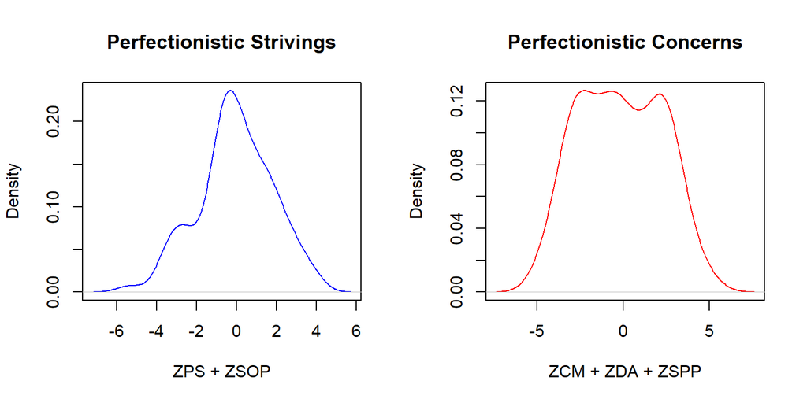

```r
par(mfrow = c(1, 2))

plot(density(na.omit(qu2$Perf_Strivings)),
     col = "blue",
     main = "Perfectionistic Strivings",
     xlab = "ZPS + ZSOP")

plot(density(na.omit(qu2$Perf_Concerns)),
     col = "red",
     main = "Perfectionistic Concerns",
     xlab = "ZCM + ZDA + ZSPP")
```

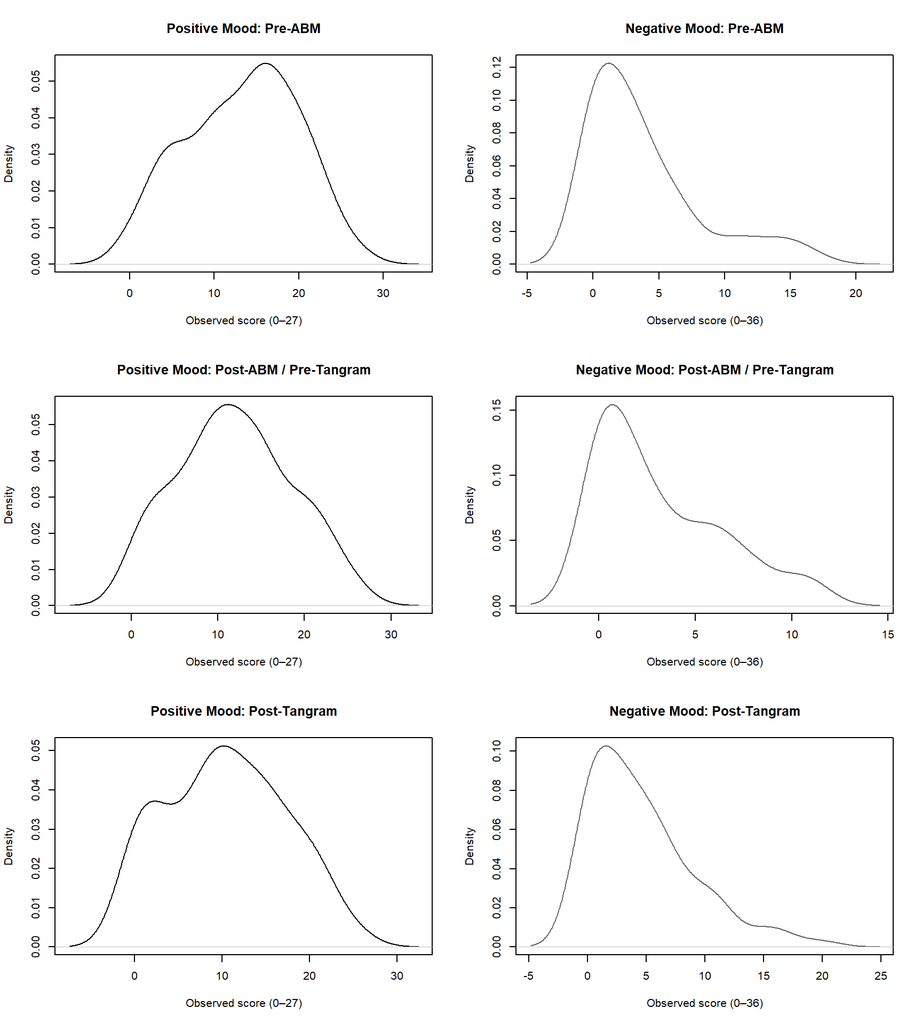

```r
par(mfrow = c(3, 2))

plot(density(na.omit(qu2$POS_2)),
     col = "black",
     main = "Positive Mood: Pre-ABM",
     xlab = "Observed score (0–27)")

plot(density(na.omit(qu2$NEG_2)),
     col = "grey40",
     main = "Negative Mood: Pre-ABM",
     xlab = "Observed score (0–36)")

plot(density(na.omit(qu2$POS_3)),
     col = "black",
     main = "Positive Mood: Post-ABM / Pre-Tangram",
     xlab = "Observed score (0–27)")

plot(density(na.omit(qu2$NEG_3)),
     col = "grey40",
     main = "Negative Mood: Post-ABM / Pre-Tangram",
     xlab = "Observed score (0–36)")

plot(density(na.omit(qu2$POS_4)),
     col = "black",
     main = "Positive Mood: Post-Tangram",
     xlab = "Observed score (0–27)")

plot(density(na.omit(qu2$NEG_4)),
     col = "grey40",
     main = "Negative Mood: Post-Tangram",
     xlab = "Observed score (0–36)")
```

```r
round(psych::describe(qu2[c(
  "POS_2", "NEG_2", "POS_3", "NEG_3", "POS_4", "NEG_4"
)]), 2)
```

```
##       vars  n  mean   sd median trimmed  mad min max range  skew kurtosis   se
## POS_2    1 92 13.27 6.58   14.5   13.35 6.67   0  27    27 -0.16    -0.89 0.69
## NEG_2    2 92  3.85 4.36    3.0    3.07 4.45   0  17    17  1.34     0.98 0.45
## POS_3    3 92 11.89 6.56   11.5   11.81 6.67   0  26    26  0.11    -0.81 0.68
## NEG_3    4 92  3.15 3.25    2.0    2.72 2.97   0  11    11  0.88    -0.31 0.34
## POS_4    5 92 10.45 6.81   10.0   10.30 7.41   0  25    25  0.11    -0.95 0.71
## NEG_4    6 92  4.64 4.46    3.5    4.03 3.71   0  20    20  1.16     1.00 0.46
```

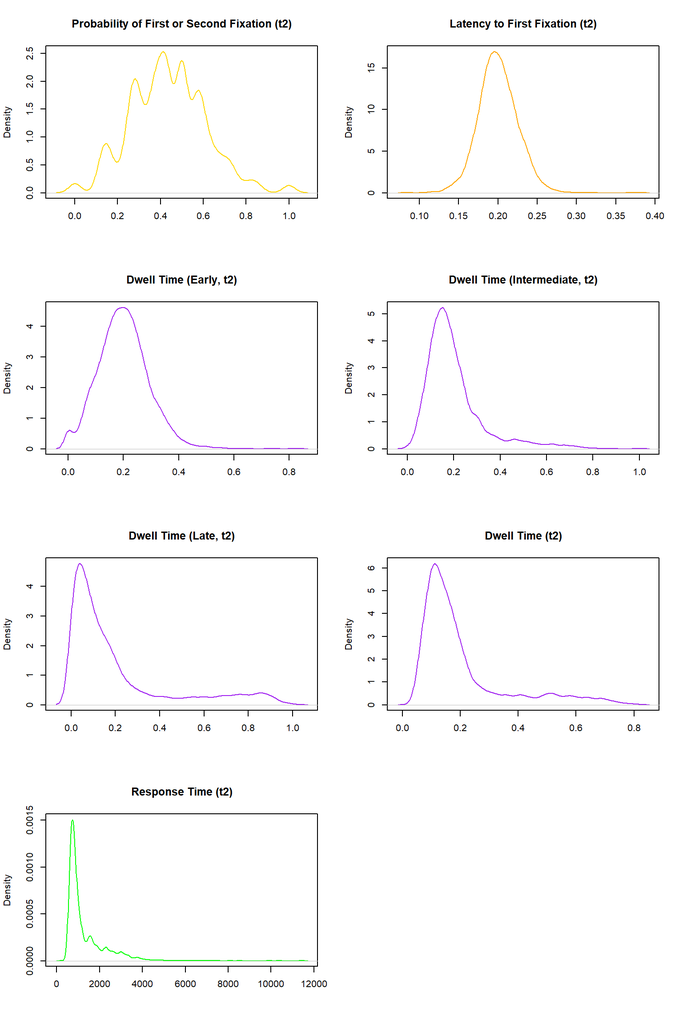

```r
par(mfrow = c(4, 2))

plot(density(na.omit(et_qu2$first_fix_prob_2)),
     col='gold',
     main='Probability of First or Second Fixation (t2)',
     xlab ='')

plot(density(na.omit(et_qu2$first_fix_latency_2)),
     col='orange',
     main='Latency to First Fixation (t2)',
     xlab = '')

plot(density(na.omit(et_qu2$dwell_time_early_2)),
     col='purple',
     main='Dwell Time (Early, t2)',
     xlab = '')

plot(density(na.omit(et_qu2$dwell_time_intermediate_2)),
     col='purple',
     main='Dwell Time (Intermediate, t2)',
     xlab = '')

plot(density(na.omit(et_qu2$dwell_time_late_2)),
     col='purple',
     main='Dwell Time (Late, t2)',
     xlab = '')

plot(density(na.omit(et_qu2$dwell_time_2)),
     col='purple', main='Dwell Time (t2)',
     xlab = '')

plot(density(na.omit(rt_qu2$response_time_2)),
     col='green',
     main='Response Time (t2)',
     xlab='')
```

_________________________________________________________________

# i) Model Inputs and Predictor Coding

## Semantic Coding

Semantic category was represented as the same five-level factor used in Study 1, with Neutral specified as the reference category. For response-time models, semantic category referred to the changed word; for eye-tracking models, it referred to the AOI category. Planned `emmeans` comparisons tested emotional valence (positive versus negative), success versus failure, performance-irrelevant versus performance-relevant, and neutral versus non-neutral content following a supported omnibus interaction.

```r
semantic_levels <- c("Neutral", "Positive", "Negative", "Success", "Failure")

rt_qu2$Change_category_f <- factor(
  rt_qu2$Change_category,
  levels = semantic_levels
)
stopifnot(levels(rt_qu2$Change_category_f)[1] == "Neutral")

# Planned comparisons among factor levels. Each vector is explicitly named to
# show the category mapping and uses the agreed integer coding.
semantic_planned <- list(
  # Positive versus negative, irrespective of performance relevance
  positive_vs_negative = c(
    Neutral = 0, Positive = -1, Negative = 1, Success = -1, Failure = 1
  ),
  # Success versus failure
  success_vs_failure = c(
    Neutral = 0, Positive = 0, Negative = 0, Success = -1, Failure = 1
  ),
  # Performance-irrelevant versus performance-relevant
  performance_irrelevant_vs_relevant = c(
    Neutral = -2, Positive = -2, Negative = -2, Success = 3, Failure = 3
  ),
  # Neutral versus non-neutral
  neutral_vs_nonneutral = c(
    Neutral = -4, Positive = 1, Negative = 1, Success = 1, Failure = 1
  )
)

stopifnot(
  all(vapply(semantic_planned, sum, numeric(1)) == 0),
  all(vapply(semantic_planned, function(x) identical(names(x), semantic_levels),
             logical(1)))
)
```

```r
et_qu2$IA_LABEL_f <- factor(
  et_qu2$IA_LABEL,
  levels = semantic_levels
)
stopifnot(levels(et_qu2$IA_LABEL_f)[1] == "Neutral")
```

## ABM Condition

ABM Condition was coded as a three-level factor (Control, Success, Failure), with the control condition as the reference category. Consequently, the condition coefficients and condition-by-semantic-category interaction coefficients compare failure- and success-oriented training with the control condition, which provides the intended test of each active training condition against sham training.

```r
qu2$Condition <- relevel(as.factor(qu2$Condition), ref = "Control")
rt_qu2$Condition <- relevel(as.factor(rt_qu2$Condition), ref = "Control")
et_qu2$Condition <- relevel(as.factor(et_qu2$Condition), ref = "Control")
stopifnot(
  levels(qu2$Condition)[1] == "Control",
  levels(rt_qu2$Condition)[1] == "Control",
  levels(et_qu2$Condition)[1] == "Control"
)
```

## Centering Predictors

Perfectionistic Strivings and Perfectionistic Concerns were mean-centered prior to analysis to reduce multicollinearity and facilitate interpretation.

```r
qu2$Perf_Strivings_c <- qu2$Perf_Strivings - mean(qu2$Perf_Strivings, na.rm = TRUE)
qu2$Perf_Concerns_c  <- qu2$Perf_Concerns  - mean(qu2$Perf_Concerns, na.rm = TRUE)

rt_qu2$Perf_Strivings_c <- rt_qu2$Perf_Strivings - mean(rt_qu2$Perf_Strivings, na.rm = TRUE)
rt_qu2$Perf_Concerns_c  <- rt_qu2$Perf_Concerns  - mean(rt_qu2$Perf_Concerns, na.rm = TRUE)

et_qu2$Perf_Strivings_c <- et_qu2$Perf_Strivings - mean(et_qu2$Perf_Strivings, na.rm = TRUE)
et_qu2$Perf_Concerns_c  <- et_qu2$Perf_Concerns  - mean(et_qu2$Perf_Concerns, na.rm = TRUE)
```

## Participant and Block Structure

```r
rt_qu2$subject_id_2 <- as.factor(rt_qu2$subject_id_2)
rt_qu2$subject_id_1 <- as.factor(rt_qu2$subject_id_1)
rt_qu2$block_id <- as.factor(rt_qu2$block_id)
rt_qu2$block_nr_1 <- as.integer(rt_qu2$block_nr_1)
rt_qu2$block_nr_2 <- as.integer(rt_qu2$block_nr_2)
rt_qu2$trial_nr_1 <- as.integer(rt_qu2$trial_nr_1)
rt_qu2$trial_nr_2 <- as.integer(rt_qu2$trial_nr_2)
rt_qu2$trial_nr_1_c <- rt_qu2$trial_nr_1 - mean(rt_qu2$trial_nr_1, na.rm = TRUE)
rt_qu2$trial_nr_2_c <- rt_qu2$trial_nr_2 - mean(rt_qu2$trial_nr_2, na.rm = TRUE)

et_qu2$subject_id_2 <- as.factor(et_qu2$subject_id_2)
et_qu2$subject_id_1 <- as.factor(et_qu2$subject_id_1)
et_qu2$block_id <- as.factor(et_qu2$block_id)
et_qu2$block_nr_1 <- as.integer(et_qu2$block_nr_1)
et_qu2$block_nr_2 <- as.integer(et_qu2$block_nr_2)
et_qu2$block_nr_c <- et_qu2$block_nr_2 - mean(et_qu2$block_nr_2, na.rm = TRUE)
```

For eye-tracking analyses, a binary indicator (Change_category01) was created to denote whether a given AOI matched the semantic category targeted by the change rule within a block (0 = non-target, 1 = target).

```r
et_qu2$Change_category <- as.factor(et_qu2$Change_category)

et_qu2$Change_category01 <- 0
et_qu2$Change_category01 <- as.integer(
  as.character(et_qu2$IA_LABEL) == as.character(et_qu2$Change_category)
)
```

_________________________________________________________________

# ii) Task Performance and Control Analysis

This section reports analyses assessing task performance over time and baseline equivalence across ABM conditions.

Given similar group sizes and the robustness of ANOVA to moderate violations of homogeneity of variance, no additional variance homogeneity tests were conducted for these control analyses.

## Task Performance

Paired-samples t-tests were conducted to examine pre–post changes in response accuracy and rule awareness.

```r
# Response accuracy
t.test(accuracy_1, accuracy_2, paired = TRUE)
```

```
##
##  Paired t-test
##
## data:  accuracy_1 and accuracy_2
## t = -0.50828, df = 91, p-value = 0.6125
## alternative hypothesis: true mean difference is not equal to 0
## 95 percent confidence interval:
##  -0.4801326  0.2844804
## sample estimates:
## mean difference
##     -0.09782609
```

```r
# Rule awareness
t.test(rule_awareness_1, rule_awareness_2, paired = TRUE)
```

```
##
##  Paired t-test
##
## data:  rule_awareness_1 and rule_awareness_2
## t = -6.6722, df = 91, p-value = 1.925e-09
## alternative hypothesis: true mean difference is not equal to 0
## 95 percent confidence interval:
##  -1.918354 -1.038167
## sample estimates:
## mean difference
##       -1.478261
```

Response accuracy remained stable from T1 to T2, whereas rule awareness increased significantly over time, indicating improved detection of the semantic rule across blocks.

## Group Equivalence

One-way ANOVAs were conducted to assess equivalence across ABM conditions for task performance, perfectionism, and baseline depressive and anxiety symptoms.

```r
# Tangram performance
fit_Tangrams <- lm(Tangrams ~ Condition, data = qu2)
anova(fit_Tangrams)
```

```
## Analysis of Variance Table
##
## Response: Tangrams
##           Df Sum Sq Mean Sq F value Pr(>F)
## Condition  2  0.280 0.14004  0.2311 0.7941
## Residuals 89 53.926 0.60592
```

```r
# Perfectionism
fit_Strivings <- lm(Perf_Strivings ~ Condition, data = qu2)
anova(fit_Strivings)
```

```
## Analysis of Variance Table
##
## Response: Perf_Strivings
##           Df  Sum Sq Mean Sq F value Pr(>F)
## Condition  2   7.221  3.6104  1.0429 0.3567
## Residuals 89 308.103  3.4618
```

```r
fit_Concerns <- lm(Perf_Concerns ~ Condition, data = qu2)
anova(fit_Concerns)
```

```
## Analysis of Variance Table
##
## Response: Perf_Concerns
##           Df Sum Sq Mean Sq F value Pr(>F)
## Condition  2   6.63  3.3160  0.5683 0.5685
## Residuals 89 519.33  5.8352
```

```r
# Baseline depressive and anxiety symptom control variables
fit_Depression <- lm(CESD ~ Condition, data = qu2)
anova(fit_Depression)
```

```
## Analysis of Variance Table
##
## Response: CESD
##           Df  Sum Sq Mean Sq F value  Pr(>F)
## Condition  2   700.4  350.20  3.0939 0.05023 .
## Residuals 89 10074.0  113.19
## ---
## Signif. codes:  0 '***' 0.001 '**' 0.01 '*' 0.05 '.' 0.1 ' ' 1
```

```r
fit_Anxiety <- lm(GAD7 ~ Condition, data = qu2)
anova(fit_Anxiety)
```

```
## Analysis of Variance Table
##
## Response: GAD7
##           Df  Sum Sq Mean Sq F value  Pr(>F)
## Condition  2  190.14  95.069  2.9979 0.05495 .
## Residuals 89 2822.33  31.712
## ---
## Signif. codes:  0 '***' 0.001 '**' 0.01 '*' 0.05 '.' 0.1 ' ' 1
```

No differences between ABM conditions were observed for Tangram performance, Perfectionistic Strivings or Perfectionistic Concerns, or baseline depressive and anxiety symptoms, indicating successful group equivalence.

_________________________________________________________________

# ii) Primary Manipulation Checks: Post-ABM Attention Conditional on Pre-ABM Attention

The manipulation checks tested whether the ABM conditions altered post-modification attentional allocation in the intended directions. Each post-ABM attentional measure was modeled conditional on its corresponding pre-ABM value. This baseline-adjusted formulation controls for pre-existing individual differences, preserves the measurement scale and distribution of each post-ABM outcome, and avoids incorporating baseline measurement error directly into a change score.

Eye-tracking models were estimated at the block-by-semantic-category level and included a participant random intercept and an uncorrelated participant-specific slope for `Change_category01`. Mean-centered block presentation order was included as a fixed time covariate. The trial-level response-time model included a participant random intercept and mean-centered trial presentation order. A block-identity random intercept was considered but omitted from the primary models because it produced singular or non-positive-definite solutions for several outcomes and explained negligible variance where estimable. `Change_category01` controlled whether the area of interest matched the semantic category targeted by the block rule. ABM condition was entered as a three-level factor with the control condition as the reference category; thus, all condition coefficients and condition-by-category coefficients compare failure- or success-oriented training with control.

Post-ABM eye-tracking proportions were analyzed using beta mixed-effects models with logit links. Values at 0 and 1 were moved slightly into the open unit interval before fitting. Post-ABM response times were analyzed using a gamma mixed-effects model with a log link because response times were strictly positive and right-skewed (Lo & Andrews, 2015). Rule awareness was included in each dispersion submodel. For every outcome, the manipulation check compared a model containing semantic category as a five-level factor with a model that added its interaction with ABM condition. Neutral stimuli were the reference category. The omnibus comparison evaluated whether the manipulation altered allocation across semantic categories; when supported, the factor coefficients directly characterized the category-specific differences from the reference category.

### Manipulation-Check Model Specification

For the beta eye-tracking outcomes, the mean submodel was:

$$\begin{aligned}
g(\mu_{ij}) ={}& \beta_0 + \beta_1 Pre_{ij} + \sum_{k=1}^{4}\alpha_k
C_{k,ij} + \sum_{h=1}^{2}\lambda_h Condition_{h,j} + \beta_2
BlockOrder_{ij} + \delta ChangeCategory_{ij} \\
&+ \sum_{k=1}^{4}\sum_{h=1}^{2}\gamma_{kh}(C_{k,ij}\times
Condition_{h,j}) \\
&+ u_{0j} + u_{1j}ChangeCategory_{ij},
\end{aligned}$$

where $g(\cdot)$ is the logit link, $Pre_{ij}$ is the corresponding pre-ABM attentional value, $C_{k,ij}$ represents the four non-neutral semantic-category indicators, the two $Condition_{h,j}$ indicators compare failure- and success-oriented training with control, and $BlockOrder_{ij}$ is mean-centered block order. The beta precision submodel was:

$$\log(\phi_{ij}) = \eta_0 + \eta_1 BR_{ij},$$

where $BR_{ij}$ denotes post-ABM rule awareness and larger $\phi_{ij}$ indicates greater conditional precision.

For response time, the gamma mean submodel was:

$$\begin{aligned}
\log(\mu_{ij}) ={}& \beta_0 + \beta_1 PreRT_{ij} +
\sum_{k=1}^{4}\alpha_k C_{k,ij} + \sum_{h=1}^{2}\lambda_h
Condition_{h,j} + \beta_2 TrialOrder_{ij} \\
&+ \sum_{k=1}^{4}\sum_{h=1}^{2}\gamma_{kh}(C_{k,ij}\times
Condition_{h,j}) \\
&+ u_{0j},
\end{aligned}$$

with dispersion submodel

$$\log(\sigma_{ij}) = \eta_0 + \eta_1 BR_{ij}.$$

Here, $PreRT_{ij}$ is the corresponding pre-ABM response time, $TrialOrder_{ij}$ is mean-centered trial order, and $\sigma_{ij}$ is the gamma dispersion parameter.

The corresponding pre-ABM attentional value was mean-centered before model fitting. A centered value of zero therefore represents the sample-average pre-ABM value, and the estimated marginal means describe model-adjusted expected **post-ABM levels** for observations at that average baseline. Accordingly, active-condition-versus-control comparisons test whether the groups differ in adjusted post-ABM attentional allocation when compared at the same average pre-ABM level.

```r
squeeze01_study2 <- function(x) {
  n <- sum(!is.na(x))
  ifelse(is.na(x), NA_real_, (x * (n - 1) + 0.5) / n)
}

mc_et2 <- et_qu2 %>%
  mutate(
    first_fix_prob_1_c = first_fix_prob_1 - mean(first_fix_prob_1, na.rm = TRUE),
    first_fix_latency_1_c = first_fix_latency_1 - mean(first_fix_latency_1, na.rm = TRUE),
    dwell_time_early_1_c = dwell_time_early_1 - mean(dwell_time_early_1, na.rm = TRUE),
    dwell_time_intermediate_1_c = dwell_time_intermediate_1 - mean(dwell_time_intermediate_1, na.rm = TRUE),
    dwell_time_late_1_c = dwell_time_late_1 - mean(dwell_time_late_1, na.rm = TRUE),
    dwell_time_1_c = dwell_time_1 - mean(dwell_time_1, na.rm = TRUE),
    first_fix_prob_2_t01 = squeeze01_study2(first_fix_prob_2),
    first_fix_latency_2_t01 = squeeze01_study2(first_fix_latency_2),
    dwell_time_early_2_t01 = squeeze01_study2(dwell_time_early_2),
    dwell_time_intermediate_2_t01 = squeeze01_study2(dwell_time_intermediate_2),
    dwell_time_late_2_t01 = squeeze01_study2(dwell_time_late_2),
    dwell_time_2_t01 = squeeze01_study2(dwell_time_2)
  )

mc_rt2 <- rt_qu2 %>%
  mutate(
    response_time_1_c = response_time_1 - mean(response_time_1, na.rm = TRUE)
  )
```

For outcomes with a supported omnibus interaction, the following helper first reports the difference between each active condition and control within each semantic category. It then reports the corresponding active-versus-control differences for the four planned theoretical contrasts. Because Condition and semantic category are both factors, these follow-ups use estimated marginal means rather than `emtrends()`, which is reserved for slopes of continuous predictors. No follow-up table is produced when the omnibus interaction is not significant.

```r
manipulation_emmeans_followup <- function(reduced, full, semantic_factor,
                                          alpha = .05) {
  model_comparison <- anova(reduced, full)
  p_column <- grep("^Pr\\(", names(model_comparison), value = TRUE)[1]
  omnibus_p <- model_comparison[[p_column]][2]

  if (is.na(omnibus_p) || omnibus_p >= alpha) {
    message("Omnibus interaction unsupported; follow-up comparisons omitted.")
    return(invisible(NULL))
  }

  category_formula <- as.formula(
    paste("~ Condition |", semantic_factor)
  )
  category_means <- emmeans(full, category_formula)
  category_condition_differences <- contrast(
    category_means,
    method = "trt.vs.ctrl",
    ref = "Control",
    by = semantic_factor,
    adjust = "none"
  )

  print(as.data.frame(summary(
    category_condition_differences,
    infer = c(TRUE, TRUE)
  )))

  semantic_formula <- as.formula(
    paste("~", semantic_factor, "| Condition")
  )
  semantic_means <- emmeans(full, semantic_formula)

  theoretical_by_condition <- contrast(
    semantic_means,
    method = semantic_planned,
    by = "Condition",
    adjust = "none"
  )

  theoretical_condition_differences <- contrast(
    update(theoretical_by_condition, by = "contrast"),
    method = "trt.vs.ctrl",
    ref = "Control",
    adjust = "none"
  )

  essential_table <- as.data.frame(summary(
    theoretical_condition_differences,
    infer = c(TRUE, TRUE)
  ))
  essential_table$omnibus_p <- omnibus_p
  essential_table$omnibus_supported <- TRUE

  essential_table
}
```

## Eye-Tracking Outcomes

### Probability of First or Second Fixation

```r
mc_first_fix_prob_reduced <- glmmTMB(
  first_fix_prob_2_t01 ~
    first_fix_prob_1_c + Condition +
    IA_LABEL_f +
    block_nr_c + Change_category01 +
    #(1 | block_id) +
    (1 + Change_category01 || subject_id_2),
  REML = FALSE,
  family = beta_family(link = "logit"),
  dispformula = ~ guessed_block_rule_2,
  data = mc_et2,
  na.action = na.omit
)

mc_first_fix_prob <- update(
  mc_first_fix_prob_reduced,
  . ~ . + IA_LABEL_f:Condition
)

summary(mc_first_fix_prob)
```

```
##  Family: beta  ( logit )
## Formula:
## first_fix_prob_2_t01 ~ first_fix_prob_1_c + Condition + IA_LABEL_f +
##     block_nr_c + Change_category01 + (1 + Change_category01 ||
##     subject_id_2) + Condition:IA_LABEL_f
## Dispersion:                            ~guessed_block_rule_2
## Data: mc_et2
##
##      AIC      BIC   logLik deviance df.resid
##  -1649.6  -1508.2    846.8  -1693.6     4562
##
## Random effects:
##
## Conditional model:
##  Groups       Name              Variance Std.Dev. Corr
##  subject_id_2 (Intercept)       0.03428  0.1851
##               Change_category01 0.06252  0.2500   0.00
## Number of obs: 4584, groups:  subject_id_2, 92
##
## Conditional model:
##                                      Estimate Std. Error z value Pr(>|z|)
## (Intercept)                         -0.287924   0.061353  -4.693 2.69e-06 ***
## first_fix_prob_1_c                   1.294052   0.081409  15.896  < 2e-16 ***
## ConditionFailure                     0.123518   0.085782   1.440 0.149897
## ConditionSuccess                     0.104661   0.083732   1.250 0.211317
## IA_LABEL_fPositive                   0.164954   0.070735   2.332 0.019700 *
## IA_LABEL_fNegative                   0.054392   0.070868   0.768 0.442778
## IA_LABEL_fSuccess                    0.117609   0.070468   1.669 0.095123 .
## IA_LABEL_fFailure                    0.086605   0.070726   1.225 0.220761
## block_nr_c                           0.016407   0.004376   3.749 0.000177 ***
## Change_category01                   -0.195183   0.041124  -4.746 2.07e-06 ***
## ConditionFailure:IA_LABEL_fPositive -0.129980   0.099447  -1.307 0.191206
## ConditionSuccess:IA_LABEL_fPositive -0.251704   0.096877  -2.598 0.009372 **
## ConditionFailure:IA_LABEL_fNegative -0.175128   0.099720  -1.756 0.079056 .
## ConditionSuccess:IA_LABEL_fNegative -0.153856   0.096977  -1.587 0.112622
## ConditionFailure:IA_LABEL_fSuccess   0.006613   0.098586   0.067 0.946517
## ConditionSuccess:IA_LABEL_fSuccess  -0.233132   0.096467  -2.417 0.015662 *
## ConditionFailure:IA_LABEL_fFailure   0.016288   0.099385   0.164 0.869818
## ConditionSuccess:IA_LABEL_fFailure  -0.113751   0.097042  -1.172 0.241121
## ---
## Signif. codes:  0 '***' 0.001 '**' 0.01 '*' 0.05 '.' 0.1 ' ' 1
##
## Dispersion model:
##                      Estimate Std. Error z value Pr(>|z|)
## (Intercept)           1.48085    0.06607  22.414   <2e-16 ***
## guessed_block_rule_2  0.03019    0.06929   0.436    0.663
## ---
## Signif. codes:  0 '***' 0.001 '**' 0.01 '*' 0.05 '.' 0.1 ' ' 1
```

```r
anova(mc_first_fix_prob_reduced, mc_first_fix_prob)
```

```
## Data: mc_et2
## Models:
## mc_first_fix_prob_reduced: first_fix_prob_2_t01 ~ first_fix_prob_1_c + Condition + IA_LABEL_f + , zi=~0, disp=~guessed_block_rule_2
## mc_first_fix_prob_reduced:     block_nr_c + Change_category01 + (1 + Change_category01 || , zi=~0, disp=~guessed_block_rule_2
## mc_first_fix_prob_reduced:     subject_id_2), zi=~0, disp=~guessed_block_rule_2
## mc_first_fix_prob: first_fix_prob_2_t01 ~ first_fix_prob_1_c + Condition + IA_LABEL_f + , zi=~0, disp=~guessed_block_rule_2
## mc_first_fix_prob:     block_nr_c + Change_category01 + (1 + Change_category01 || , zi=~0, disp=~guessed_block_rule_2
## mc_first_fix_prob:     subject_id_2) + Condition:IA_LABEL_f, zi=~0, disp=~guessed_block_rule_2
##                           Df     AIC     BIC logLik deviance  Chisq Chi Df
## mc_first_fix_prob_reduced 14 -1648.8 -1558.8 838.40  -1676.8
## mc_first_fix_prob         22 -1649.6 -1508.2 846.82  -1693.6 16.835      8
##                           Pr(>Chisq)
## mc_first_fix_prob_reduced
## mc_first_fix_prob            0.03187 *
## ---
## Signif. codes:  0 '***' 0.001 '**' 0.01 '*' 0.05 '.' 0.1 ' ' 1
```

```r
manipulation_emmeans_followup(
  mc_first_fix_prob_reduced, mc_first_fix_prob, "IA_LABEL_f"
)
```

```
## IA_LABEL_f = Neutral:
##  contrast             estimate         SE  df   asymp.LCL  asymp.UCL z.ratio
##  Failure - Control  0.12351759 0.08578236 Inf -0.04461274 0.29164791   1.440
##  Success - Control  0.10466073 0.08373178 Inf -0.05945054 0.26877201   1.250
##  p.value
##   0.1499
##   0.2113
##
## IA_LABEL_f = Positive:
##  contrast             estimate         SE  df   asymp.LCL  asymp.UCL z.ratio
##  Failure - Control -0.00646210 0.08580638 Inf -0.17463951 0.16171532  -0.075
##  Success - Control -0.14704321 0.08367325 Inf -0.31103978 0.01695335  -1.757
##  p.value
##   0.9400
##   0.0789
##
## IA_LABEL_f = Negative:
##  contrast             estimate         SE  df   asymp.LCL  asymp.UCL z.ratio
##  Failure - Control -0.05161016 0.08609949 Inf -0.22036207 0.11714175  -0.599
##  Success - Control -0.04919499 0.08368388 Inf -0.21321239 0.11482240  -0.588
##  p.value
##   0.5489
##   0.5566
##
## IA_LABEL_f = Success:
##  contrast             estimate         SE  df   asymp.LCL  asymp.UCL z.ratio
##  Failure - Control  0.13013089 0.08488573 Inf -0.03624208 0.29650387   1.533
##  Success - Control -0.12847079 0.08336178 Inf -0.29185688 0.03491530  -1.541
##  p.value
##   0.1253
##   0.1233
##
## IA_LABEL_f = Failure:
##  contrast             estimate         SE  df   asymp.LCL  asymp.UCL z.ratio
##  Failure - Control  0.13980572 0.08578291 Inf -0.02832569 0.30793713   1.630
##  Success - Control -0.00909032 0.08395891 Inf -0.17364676 0.15546612  -0.108
##  p.value
##   0.1032
##   0.9138
##
## Results are averaged over the levels of: Change_category01
## Results are given on the log odds ratio (not the response) scale.
## Confidence level used: 0.95
```

```
## contrast = positive_vs_negative:
##  contrast1           estimate        SE  df  asymp.LCL  asymp.UCL z.ratio
##  Failure - Control -0.0354732 0.1401357 Inf -0.3101342  0.2391877  -0.253
##  Success - Control  0.2172287 0.1368113 Inf -0.0509165  0.4853739   1.588
##  p.value omnibus_p omnibus_supported
##   0.8002 0.0318689 TRUE
##   0.1123 0.0318689 TRUE
##
## contrast = success_vs_failure:
##  contrast1           estimate        SE  df  asymp.LCL  asymp.UCL z.ratio
##  Failure - Control  0.0096748 0.0984644 Inf -0.1833118  0.2026615   0.098
##  Success - Control  0.1193805 0.0966001 Inf -0.0699522  0.3087131   1.236
##  p.value omnibus_p omnibus_supported
##   0.9217 0.0318689 TRUE
##   0.2165 0.0318689 TRUE
##
## contrast = performance_irrelevant_vs_relevant:
##  contrast1           estimate        SE  df  asymp.LCL  asymp.UCL z.ratio
##  Failure - Control  0.6789192 0.3835296 Inf -0.0727851  1.4306235   1.770
##  Success - Control -0.2295284 0.3749413 Inf -0.9643997  0.5053430  -0.612
##  p.value omnibus_p omnibus_supported
##   0.0767 0.0318689 TRUE
##   0.5404 0.0318689 TRUE
##
## contrast = neutral_vs_nonneutral:
##  contrast1           estimate        SE  df  asymp.LCL  asymp.UCL z.ratio
##  Failure - Control -0.2822060 0.3142870 Inf -0.8981972  0.3337852  -0.898
##  Success - Control -0.7524423 0.3063351 Inf -1.3528481 -0.1520364  -2.456
##  p.value omnibus_p omnibus_supported
##   0.3692 0.0318689 TRUE
##   0.0140 0.0318689 TRUE
##
## Results are averaged over the levels of: Change_category01
## Results are given on the log odds ratio (not the response) scale.
## Confidence level used: 0.95
```

### Latency to First Fixation

```r
mc_first_fix_latency_reduced <- glmmTMB(
  first_fix_latency_2_t01 ~
    first_fix_latency_1_c + Condition +
    IA_LABEL_f +
    block_nr_c + Change_category01 +
    #(1 | block_id) +
    (1 + Change_category01 || subject_id_2),
  REML = FALSE,
  family = beta_family(link = "logit"),
  dispformula = ~ guessed_block_rule_2,
  data = mc_et2,
  na.action = na.omit
)

mc_first_fix_latency <- update(
  mc_first_fix_latency_reduced,
  . ~ . + IA_LABEL_f:Condition
)

summary(mc_first_fix_latency)
```

```
##  Family: beta  ( logit )
## Formula:
## first_fix_latency_2_t01 ~ first_fix_latency_1_c + Condition +
##     IA_LABEL_f + block_nr_c + Change_category01 + (1 + Change_category01 ||
##     subject_id_2) + Condition:IA_LABEL_f
## Dispersion:                               ~guessed_block_rule_2
## Data: mc_et2
##
##      AIC      BIC   logLik deviance df.resid
## -21053.5 -20912.0  10548.7 -21097.5     4562
##
## Random effects:
##
## Conditional model:
##  Groups       Name              Variance  Std.Dev.  Corr
##  subject_id_2 (Intercept)       1.715e-12 1.309e-06
##               Change_category01 1.330e-10 1.153e-05 0.00
## Number of obs: 4584, groups:  subject_id_2, 92
##
## Conditional model:
##                                       Estimate Std. Error z value Pr(>|z|)
## (Intercept)                         -1.3778215  0.0089322 -154.25  < 2e-16 ***
## first_fix_latency_1_c                1.4204594  0.0928377   15.30  < 2e-16 ***
## ConditionFailure                    -0.0018860  0.0124645   -0.15  0.87973
## ConditionSuccess                    -0.0224022  0.0121827   -1.84  0.06594 .
## IA_LABEL_fPositive                  -0.0367597  0.0126175   -2.91  0.00358 **
## IA_LABEL_fNegative                  -0.0130262  0.0125508   -1.04  0.29933
## IA_LABEL_fSuccess                   -0.0102102  0.0125534   -0.81  0.41602
## IA_LABEL_fFailure                   -0.0042249  0.0125424   -0.34  0.73623
## block_nr_c                          -0.0001425  0.0007797   -0.18  0.85499
## Change_category01                    0.0234230  0.0055749    4.20 2.65e-05 ***
## ConditionFailure:IA_LABEL_fPositive  0.0218422  0.0177160    1.23  0.21761
## ConditionSuccess:IA_LABEL_fPositive  0.0402521  0.0172895    2.33  0.01991 *
## ConditionFailure:IA_LABEL_fNegative  0.0072960  0.0176456    0.41  0.67926
## ConditionSuccess:IA_LABEL_fNegative  0.0335931  0.0172370    1.95  0.05131 .
## ConditionFailure:IA_LABEL_fSuccess  -0.0152912  0.0176748   -0.87  0.38696
## ConditionSuccess:IA_LABEL_fSuccess   0.0224057  0.0172314    1.30  0.19350
## ConditionFailure:IA_LABEL_fFailure  -0.0033516  0.0176454   -0.19  0.84936
## ConditionSuccess:IA_LABEL_fFailure   0.0140927  0.0172240    0.82  0.41324
## ---
## Signif. codes:  0 '***' 0.001 '**' 0.01 '*' 0.05 '.' 0.1 ' ' 1
##
## Dispersion model:
##                      Estimate Std. Error z value Pr(>|z|)
## (Intercept)           5.56974    0.06932   80.34   <2e-16 ***
## guessed_block_rule_2  0.03142    0.07269    0.43    0.666
## ---
## Signif. codes:  0 '***' 0.001 '**' 0.01 '*' 0.05 '.' 0.1 ' ' 1
```

```r
anova(mc_first_fix_latency_reduced, mc_first_fix_latency)
```

```
## Data: mc_et2
## Models:
## mc_first_fix_latency_reduced: first_fix_latency_2_t01 ~ first_fix_latency_1_c + Condition + , zi=~0, disp=~guessed_block_rule_2
## mc_first_fix_latency_reduced:     IA_LABEL_f + block_nr_c + Change_category01 + (1 + Change_category01 || , zi=~0, disp=~guessed_block_rule_2
## mc_first_fix_latency_reduced:     subject_id_2), zi=~0, disp=~guessed_block_rule_2
## mc_first_fix_latency: first_fix_latency_2_t01 ~ first_fix_latency_1_c + Condition + , zi=~0, disp=~guessed_block_rule_2
## mc_first_fix_latency:     IA_LABEL_f + block_nr_c + Change_category01 + (1 + Change_category01 || , zi=~0, disp=~guessed_block_rule_2
## mc_first_fix_latency:     subject_id_2) + Condition:IA_LABEL_f, zi=~0, disp=~guessed_block_rule_2
##                              Df    AIC    BIC logLik deviance Chisq Chi Df
## mc_first_fix_latency_reduced 14 -21058 -20968  10543   -21086
## mc_first_fix_latency         22 -21054 -20912  10549   -21098 11.19      8
##                              Pr(>Chisq)
## mc_first_fix_latency_reduced
## mc_first_fix_latency             0.1912
```

### Dwell Time (Early Phase)

```r
mc_dwell_time_early_reduced <- glmmTMB(
  dwell_time_early_2_t01 ~
    dwell_time_early_1_c + Condition +
    IA_LABEL_f +
    block_nr_c + Change_category01 +
    #(1 | block_id) +
    (1 + Change_category01 || subject_id_2),
  REML = FALSE,
  family = beta_family(link = "logit"),
  dispformula = ~ guessed_block_rule_2,
  data = mc_et2,
  na.action = na.omit
)

mc_dwell_time_early <- update(
  mc_dwell_time_early_reduced,
  . ~ . + IA_LABEL_f:Condition
)

summary(mc_dwell_time_early)
```

```
##  Family: beta  ( logit )
## Formula:
## dwell_time_early_2_t01 ~ dwell_time_early_1_c + Condition + IA_LABEL_f +
##     block_nr_c + Change_category01 + (1 + Change_category01 ||
##     subject_id_2) + Condition:IA_LABEL_f
## Dispersion:                              ~guessed_block_rule_2
## Data: mc_et2
##
##      AIC      BIC   logLik deviance df.resid
##  -8158.7  -8017.2   4101.3  -8202.7     4562
##
## Random effects:
##
## Conditional model:
##  Groups       Name              Variance Std.Dev. Corr
##  subject_id_2 (Intercept)       0.01158  0.1076
##               Change_category01 0.03554  0.1885   0.00
## Number of obs: 4584, groups:  subject_id_2, 92
##
## Conditional model:
##                                      Estimate Std. Error z value Pr(>|z|)
## (Intercept)                         -1.503286   0.043906  -34.24  < 2e-16 ***
## dwell_time_early_1_c                 2.028416   0.111021   18.27  < 2e-16 ***
## ConditionFailure                    -0.058246   0.061662   -0.94  0.34486
## ConditionSuccess                     0.103332   0.059596    1.73  0.08294 .
## IA_LABEL_fPositive                   0.174625   0.053670    3.25  0.00114 **
## IA_LABEL_fNegative                   0.059719   0.054389    1.10  0.27221
## IA_LABEL_fSuccess                    0.055092   0.054292    1.01  0.31022
## IA_LABEL_fFailure                    0.019136   0.054652    0.35  0.72624
## block_nr_c                          -0.005271   0.003342   -1.58  0.11482
## Change_category01                    0.021330   0.031008    0.69  0.49153
## ConditionFailure:IA_LABEL_fPositive -0.005821   0.075858   -0.08  0.93884
## ConditionSuccess:IA_LABEL_fPositive -0.136678   0.073408   -1.86  0.06262 .
## ConditionFailure:IA_LABEL_fNegative  0.004605   0.076970    0.06  0.95229
## ConditionSuccess:IA_LABEL_fNegative -0.057774   0.074062   -0.78  0.43535
## ConditionFailure:IA_LABEL_fSuccess   0.085446   0.076326    1.12  0.26293
## ConditionSuccess:IA_LABEL_fSuccess  -0.101153   0.074084   -1.37  0.17213
## ConditionFailure:IA_LABEL_fFailure   0.180128   0.076429    2.36  0.01843 *
## ConditionSuccess:IA_LABEL_fFailure   0.014875   0.074239    0.20  0.84119
## ---
## Signif. codes:  0 '***' 0.001 '**' 0.01 '*' 0.05 '.' 0.1 ' ' 1
##
## Dispersion model:
##                      Estimate Std. Error z value Pr(>|z|)
## (Intercept)           2.61734    0.06815   38.40   <2e-16 ***
## guessed_block_rule_2 -0.07453    0.07115   -1.05    0.295
## ---
## Signif. codes:  0 '***' 0.001 '**' 0.01 '*' 0.05 '.' 0.1 ' ' 1
```

```r
anova(mc_dwell_time_early_reduced, mc_dwell_time_early)
```

```
## Data: mc_et2
## Models:
## mc_dwell_time_early_reduced: dwell_time_early_2_t01 ~ dwell_time_early_1_c + Condition + IA_LABEL_f + , zi=~0, disp=~guessed_block_rule_2
## mc_dwell_time_early_reduced:     block_nr_c + Change_category01 + (1 + Change_category01 || , zi=~0, disp=~guessed_block_rule_2
## mc_dwell_time_early_reduced:     subject_id_2), zi=~0, disp=~guessed_block_rule_2
## mc_dwell_time_early: dwell_time_early_2_t01 ~ dwell_time_early_1_c + Condition + IA_LABEL_f + , zi=~0, disp=~guessed_block_rule_2
## mc_dwell_time_early:     block_nr_c + Change_category01 + (1 + Change_category01 || , zi=~0, disp=~guessed_block_rule_2
## mc_dwell_time_early:     subject_id_2) + Condition:IA_LABEL_f, zi=~0, disp=~guessed_block_rule_2
##                             Df     AIC     BIC logLik deviance  Chisq Chi Df
## mc_dwell_time_early_reduced 14 -8158.8 -8068.7 4093.4  -8186.8
## mc_dwell_time_early         22 -8158.7 -8017.2 4101.3  -8202.7 15.889      8
##                             Pr(>Chisq)
## mc_dwell_time_early_reduced
## mc_dwell_time_early            0.04399 *
## ---
## Signif. codes:  0 '***' 0.001 '**' 0.01 '*' 0.05 '.' 0.1 ' ' 1
```

```r
manipulation_emmeans_followup(
  mc_dwell_time_early_reduced, mc_dwell_time_early, "IA_LABEL_f"
)
```

```
## IA_LABEL_f = Neutral:
##  contrast             estimate         SE  df   asymp.LCL  asymp.UCL z.ratio
##  Failure - Control -0.05824611 0.06166153 Inf -0.17910049 0.06260827  -0.945
##  Success - Control  0.10333239 0.05959633 Inf -0.01347427 0.22013904   1.734
##  p.value
##   0.3449
##   0.0829
##
## IA_LABEL_f = Positive:
##  contrast             estimate         SE  df   asymp.LCL  asymp.UCL z.ratio
##  Failure - Control -0.06406696 0.06021264 Inf -0.18208157 0.05394765  -1.064
##  Success - Control -0.03334536 0.05863415 Inf -0.14826619 0.08157547  -0.569
##  p.value
##   0.2873
##   0.5696
##
## IA_LABEL_f = Negative:
##  contrast             estimate         SE  df   asymp.LCL  asymp.UCL z.ratio
##  Failure - Control -0.05364103 0.06154626 Inf -0.17426948 0.06698742  -0.872
##  Success - Control  0.04555875 0.05942606 Inf -0.07091418 0.16203167   0.767
##  p.value
##   0.3835
##   0.4433
##
## IA_LABEL_f = Success:
##  contrast             estimate         SE  df   asymp.LCL  asymp.UCL z.ratio
##  Failure - Control  0.02719996 0.06091686 Inf -0.09219489 0.14659482   0.447
##  Success - Control  0.00217953 0.05956162 Inf -0.11455911 0.11891817   0.037
##  p.value
##   0.6552
##   0.9708
##
## IA_LABEL_f = Failure:
##  contrast             estimate         SE  df   asymp.LCL  asymp.UCL z.ratio
##  Failure - Control  0.12188217 0.06103086 Inf  0.00226388 0.24150046   1.997
##  Success - Control  0.11820739 0.05965432 Inf  0.00128708 0.23512770   1.982
##  p.value
##   0.0458
##   0.0475
##
## Results are averaged over the levels of: Change_category01
## Results are given on the log odds ratio (not the response) scale.
## Confidence level used: 0.95
```

```
## contrast = positive_vs_negative:
##  contrast1           estimate         SE  df  asymp.LCL asymp.UCL z.ratio
##  Failure - Control  0.1051081 0.10697665 Inf -0.1045622 0.3147785   0.983
##  Success - Control  0.1949320 0.10408685 Inf -0.0090745 0.3989384   1.873
##  p.value  omnibus_p omnibus_supported
##   0.3258 0.04398865 TRUE
##   0.0611 0.04398865 TRUE
##
## contrast = success_vs_failure:
##  contrast1           estimate         SE  df  asymp.LCL asymp.UCL z.ratio
##  Failure - Control  0.0946822 0.07565993 Inf -0.0536085 0.2429729   1.251
##  Success - Control  0.1160279 0.07405664 Inf -0.0291205 0.2611762   1.567
##  p.value  omnibus_p omnibus_supported
##   0.2108 0.04398865 TRUE
##   0.1172 0.04398865 TRUE
##
## contrast = performance_irrelevant_vs_relevant:
##  contrast1           estimate         SE  df  asymp.LCL asymp.UCL z.ratio
##  Failure - Control  0.7991546 0.29421448 Inf  0.2225048 1.3758044   2.716
##  Success - Control  0.1300692 0.28634314 Inf -0.4311530 0.6912915   0.454
##  p.value  omnibus_p omnibus_supported
##   0.0066 0.04398865 TRUE
##   0.6497 0.04398865 TRUE
##
## contrast = neutral_vs_nonneutral:
##  contrast1           estimate         SE  df  asymp.LCL asymp.UCL z.ratio
##  Failure - Control  0.2643586 0.24285999 Inf -0.2116383 0.7403554   1.089
##  Success - Control -0.2807292 0.23439211 Inf -0.7401293 0.1786709  -1.198
##  p.value  omnibus_p omnibus_supported
##   0.2764 0.04398865 TRUE
##   0.2310 0.04398865 TRUE
##
## Results are averaged over the levels of: Change_category01
## Results are given on the log odds ratio (not the response) scale.
## Confidence level used: 0.95
```

### Dwell Time (Intermediate Phase)

```r
mc_dwell_time_intermediate_reduced <- glmmTMB(
  dwell_time_intermediate_2_t01 ~
    dwell_time_intermediate_1_c + Condition +
    IA_LABEL_f +
    block_nr_c + Change_category01 +
    #(1 | block_id) +
    (1 + Change_category01 || subject_id_2),
  REML = FALSE,
  family = beta_family(link = "logit"),
  dispformula = ~ guessed_block_rule_2,
  data = mc_et2,
  na.action = na.omit
)

mc_dwell_time_intermediate <- update(
  mc_dwell_time_intermediate_reduced,
  . ~ . + IA_LABEL_f:Condition
)

summary(mc_dwell_time_intermediate)
```

```
##  Family: beta  ( logit )
## Formula:
## dwell_time_intermediate_2_t01 ~ dwell_time_intermediate_1_c +
##     Condition + IA_LABEL_f + block_nr_c + Change_category01 +
##     (1 + Change_category01 || subject_id_2) + Condition:IA_LABEL_f
## Dispersion:                                     ~guessed_block_rule_2
## Data: mc_et2
##
##      AIC      BIC   logLik deviance df.resid
## -10593.5 -10452.1   5318.8 -10637.5     4562
##
## Random effects:
##
## Conditional model:
##  Groups       Name              Variance Std.Dev. Corr
##  subject_id_2 (Intercept)       0.04147  0.2036
##               Change_category01 0.48816  0.6987   0.00
## Number of obs: 4584, groups:  subject_id_2, 92
##
## Conditional model:
##                                      Estimate Std. Error z value Pr(>|z|)
## (Intercept)                         -1.624346   0.048288  -33.64  < 2e-16 ***
## dwell_time_intermediate_1_c          0.636661   0.108224    5.88 4.03e-09 ***
## ConditionFailure                    -0.137137   0.067925   -2.02   0.0435 *
## ConditionSuccess                     0.022870   0.065961    0.35   0.7288
## IA_LABEL_fPositive                  -0.004661   0.040690   -0.11   0.9088
## IA_LABEL_fNegative                   0.047886   0.040412    1.18   0.2360
## IA_LABEL_fSuccess                   -0.024150   0.040928   -0.59   0.5552
## IA_LABEL_fFailure                   -0.101452   0.041271   -2.46   0.0140 *
## block_nr_c                          -0.003192   0.002556   -1.25   0.2118
## Change_category01                    1.037796   0.075524   13.74  < 2e-16 ***
## ConditionFailure:IA_LABEL_fPositive  0.040468   0.058008    0.70   0.4854
## ConditionSuccess:IA_LABEL_fPositive  0.022350   0.055799    0.40   0.6888
## ConditionFailure:IA_LABEL_fNegative  0.040071   0.057266    0.70   0.4841
## ConditionSuccess:IA_LABEL_fNegative -0.085946   0.055664   -1.54   0.1226
## ConditionFailure:IA_LABEL_fSuccess   0.067430   0.058041    1.16   0.2453
## ConditionSuccess:IA_LABEL_fSuccess   0.008958   0.055953    0.16   0.8728
## ConditionFailure:IA_LABEL_fFailure   0.103038   0.058501    1.76   0.0782 .
## ConditionSuccess:IA_LABEL_fFailure   0.120492   0.056004    2.15   0.0314 *
## ---
## Signif. codes:  0 '***' 0.001 '**' 0.01 '*' 0.05 '.' 0.1 ' ' 1
##
## Dispersion model:
##                      Estimate Std. Error z value Pr(>|z|)
## (Intercept)           3.43697    0.07070   48.61  < 2e-16 ***
## guessed_block_rule_2 -0.25259    0.07411   -3.41 0.000654 ***
## ---
## Signif. codes:  0 '***' 0.001 '**' 0.01 '*' 0.05 '.' 0.1 ' ' 1
```

```r
anova(mc_dwell_time_intermediate_reduced, mc_dwell_time_intermediate)
```

```
## Data: mc_et2
## Models:
## mc_dwell_time_intermediate_reduced: dwell_time_intermediate_2_t01 ~ dwell_time_intermediate_1_c + , zi=~0, disp=~guessed_block_rule_2
## mc_dwell_time_intermediate_reduced:     Condition + IA_LABEL_f + block_nr_c + Change_category01 + , zi=~0, disp=~guessed_block_rule_2
## mc_dwell_time_intermediate_reduced:     (1 + Change_category01 || subject_id_2), zi=~0, disp=~guessed_block_rule_2
## mc_dwell_time_intermediate: dwell_time_intermediate_2_t01 ~ dwell_time_intermediate_1_c + , zi=~0, disp=~guessed_block_rule_2
## mc_dwell_time_intermediate:     Condition + IA_LABEL_f + block_nr_c + Change_category01 + , zi=~0, disp=~guessed_block_rule_2
## mc_dwell_time_intermediate:     (1 + Change_category01 || subject_id_2) + Condition:IA_LABEL_f, zi=~0, disp=~guessed_block_rule_2
##                                    Df    AIC    BIC logLik deviance  Chisq
## mc_dwell_time_intermediate_reduced 14 -10592 -10502 5310.1   -10620
## mc_dwell_time_intermediate         22 -10594 -10452 5318.8   -10638 17.351
##                                    Chi Df Pr(>Chisq)
## mc_dwell_time_intermediate_reduced
## mc_dwell_time_intermediate              8    0.02666 *
## ---
## Signif. codes:  0 '***' 0.001 '**' 0.01 '*' 0.05 '.' 0.1 ' ' 1
```

```r
manipulation_emmeans_followup(
  mc_dwell_time_intermediate_reduced, mc_dwell_time_intermediate, "IA_LABEL_f"
)
```

```
## IA_LABEL_f = Neutral:
##  contrast             estimate         SE  df   asymp.LCL   asymp.UCL z.ratio
##  Failure - Control -0.13713680 0.06792539 Inf -0.27026812 -0.00400548  -2.019
##  Success - Control  0.02286981 0.06596082 Inf -0.10641101  0.15215064   0.347
##  p.value
##   0.0435
##   0.7288
##
## IA_LABEL_f = Positive:
##  contrast             estimate         SE  df   asymp.LCL   asymp.UCL z.ratio
##  Failure - Control -0.09666834 0.06808874 Inf -0.23011981  0.03678313  -1.420
##  Success - Control  0.04521955 0.06605635 Inf -0.08424851  0.17468761   0.685
##  p.value
##   0.1557
##   0.4936
##
## IA_LABEL_f = Negative:
##  contrast             estimate         SE  df   asymp.LCL   asymp.UCL z.ratio
##  Failure - Control -0.09706549 0.06735960 Inf -0.22908788  0.03495691  -1.441
##  Success - Control -0.06307636 0.06588531 Inf -0.19220920  0.06605648  -0.957
##  p.value
##   0.1496
##   0.3384
##
## IA_LABEL_f = Success:
##  contrast             estimate         SE  df   asymp.LCL   asymp.UCL z.ratio
##  Failure - Control -0.06970641 0.06813406 Inf -0.20324671  0.06383389  -1.023
##  Success - Control  0.03182743 0.06623255 Inf -0.09798598  0.16164085   0.481
##  p.value
##   0.3063
##   0.6308
##
## IA_LABEL_f = Failure:
##  contrast             estimate         SE  df   asymp.LCL   asymp.UCL z.ratio
##  Failure - Control -0.03409868 0.06862591 Inf -0.16860299  0.10040563  -0.497
##  Success - Control  0.14336161 0.06629154 Inf  0.01343258  0.27329065   2.163
##  p.value
##   0.6193
##   0.0306
##
## Results are averaged over the levels of: Change_category01
## Results are given on the log odds ratio (not the response) scale.
## Confidence level used: 0.95
```

```
## contrast = positive_vs_negative:
##  contrast1          estimate         SE  df   asymp.LCL asymp.UCL z.ratio
##  Failure - Control 0.0352106 0.08209831 Inf -0.12569915 0.1961203   0.429
##  Success - Control 0.0032383 0.07918932 Inf -0.15196995 0.1584465   0.041
##  p.value  omnibus_p omnibus_supported
##   0.6680 0.02665837 TRUE
##   0.9674 0.02665837 TRUE
##
## contrast = success_vs_failure:
##  contrast1          estimate         SE  df   asymp.LCL asymp.UCL z.ratio
##  Failure - Control 0.0356077 0.05873269 Inf -0.07950623 0.1507217   0.606
##  Success - Control 0.1115342 0.05625778 Inf  0.00127097 0.2217974   1.983
##  p.value  omnibus_p omnibus_supported
##   0.5443 0.02665837 TRUE
##   0.0474 0.02665837 TRUE
##
## contrast = performance_irrelevant_vs_relevant:
##  contrast1          estimate         SE  df   asymp.LCL asymp.UCL z.ratio
##  Failure - Control 0.3503260 0.22582514 Inf -0.09228314 0.7929351   1.551
##  Success - Control 0.5155411 0.21718684 Inf  0.08986276 0.9412195   2.374
##  p.value  omnibus_p omnibus_supported
##   0.1208 0.02665837 TRUE
##   0.0176 0.02665837 TRUE
##
## contrast = neutral_vs_nonneutral:
##  contrast1          estimate         SE  df   asymp.LCL asymp.UCL z.ratio
##  Failure - Control 0.2510083 0.18299210 Inf -0.10764963 0.6096662   1.372
##  Success - Control 0.0658530 0.17632171 Inf -0.27973121 0.4114372   0.373
##  p.value  omnibus_p omnibus_supported
##   0.1702 0.02665837 TRUE
##   0.7088 0.02665837 TRUE
##
## Results are averaged over the levels of: Change_category01
## Results are given on the log odds ratio (not the response) scale.
## Confidence level used: 0.95
```

### Dwell Time (Late Phase)

```r
mc_dwell_time_late_reduced <- glmmTMB(
  dwell_time_late_2_t01 ~
    dwell_time_late_1_c + Condition +
    IA_LABEL_f +
    block_nr_c + Change_category01 +
    #(1 | block_id) +
    (1 + Change_category01 || subject_id_2),
  REML = FALSE,
  family = beta_family(link = "logit"),
  dispformula = ~ guessed_block_rule_2,
  data = mc_et2,
  na.action = na.omit
)

mc_dwell_time_late <- update(
  mc_dwell_time_late_reduced,
  . ~ . + IA_LABEL_f:Condition
)

summary(mc_dwell_time_late)
```

```
##  Family: beta  ( logit )
## Formula:
## dwell_time_late_2_t01 ~ dwell_time_late_1_c + Condition + IA_LABEL_f +
##     block_nr_c + Change_category01 + (1 + Change_category01 ||
##     subject_id_2) + Condition:IA_LABEL_f
## Dispersion:                             ~guessed_block_rule_2
## Data: mc_et2
##
##      AIC      BIC   logLik deviance df.resid
## -11340.2 -11198.7   5692.1 -11384.2     4562
##
## Random effects:
##
## Conditional model:
##  Groups       Name              Variance Std.Dev. Corr
##  subject_id_2 (Intercept)       0.2146   0.4632
##               Change_category01 1.4173   1.1905   0.00
## Number of obs: 4584, groups:  subject_id_2, 92
##
## Conditional model:
##                                      Estimate Std. Error z value Pr(>|z|)
## (Intercept)                         -2.174364   0.098744 -22.020  < 2e-16 ***
## dwell_time_late_1_c                  0.515526   0.111554   4.621 3.81e-06 ***
## ConditionFailure                    -0.206289   0.138154  -1.493 0.135390
## ConditionSuccess                     0.004720   0.134083   0.035 0.971920
## IA_LABEL_fPositive                   0.095620   0.063980   1.495 0.135036
## IA_LABEL_fNegative                   0.104115   0.063301   1.645 0.100019
## IA_LABEL_fSuccess                    0.045106   0.063388   0.712 0.476721
## IA_LABEL_fFailure                    0.029683   0.064251   0.462 0.644095
## block_nr_c                          -0.009655   0.004042  -2.389 0.016898 *
## Change_category01                    2.582808   0.131128  19.697  < 2e-16 ***
## ConditionFailure:IA_LABEL_fPositive -0.360787   0.092944  -3.882 0.000104 ***
## ConditionSuccess:IA_LABEL_fPositive -0.088995   0.088124  -1.010 0.312551
## ConditionFailure:IA_LABEL_fNegative -0.071652   0.090394  -0.793 0.427975
## ConditionSuccess:IA_LABEL_fNegative -0.095448   0.086814  -1.099 0.271571
## ConditionFailure:IA_LABEL_fSuccess  -0.082317   0.091205  -0.903 0.366762
## ConditionSuccess:IA_LABEL_fSuccess   0.069674   0.086518   0.805 0.420638
## ConditionFailure:IA_LABEL_fFailure   0.013746   0.092066   0.149 0.881312
## ConditionSuccess:IA_LABEL_fFailure  -0.042663   0.087737  -0.486 0.626784
## ---
## Signif. codes:  0 '***' 0.001 '**' 0.01 '*' 0.05 '.' 0.1 ' ' 1
##
## Dispersion model:
##                      Estimate Std. Error z value Pr(>|z|)
## (Intercept)           2.39552    0.06614   36.22   <2e-16 ***
## guessed_block_rule_2 -0.07429    0.06945   -1.07    0.285
## ---
## Signif. codes:  0 '***' 0.001 '**' 0.01 '*' 0.05 '.' 0.1 ' ' 1
```

```r
anova(mc_dwell_time_late_reduced, mc_dwell_time_late)
```

```
## Data: mc_et2
## Models:
## mc_dwell_time_late_reduced: dwell_time_late_2_t01 ~ dwell_time_late_1_c + Condition + IA_LABEL_f + , zi=~0, disp=~guessed_block_rule_2
## mc_dwell_time_late_reduced:     block_nr_c + Change_category01 + (1 + Change_category01 || , zi=~0, disp=~guessed_block_rule_2
## mc_dwell_time_late_reduced:     subject_id_2), zi=~0, disp=~guessed_block_rule_2
## mc_dwell_time_late: dwell_time_late_2_t01 ~ dwell_time_late_1_c + Condition + IA_LABEL_f + , zi=~0, disp=~guessed_block_rule_2
## mc_dwell_time_late:     block_nr_c + Change_category01 + (1 + Change_category01 || , zi=~0, disp=~guessed_block_rule_2
## mc_dwell_time_late:     subject_id_2) + Condition:IA_LABEL_f, zi=~0, disp=~guessed_block_rule_2
##                            Df    AIC    BIC logLik deviance  Chisq Chi Df
## mc_dwell_time_late_reduced 14 -11327 -11237 5677.4   -11355
## mc_dwell_time_late         22 -11340 -11199 5692.1   -11384 29.389      8
##                            Pr(>Chisq)
## mc_dwell_time_late_reduced
## mc_dwell_time_late          0.0002709 ***
## ---
## Signif. codes:  0 '***' 0.001 '**' 0.01 '*' 0.05 '.' 0.1 ' ' 1
```

```r
manipulation_emmeans_followup(
  mc_dwell_time_late_reduced, mc_dwell_time_late, "IA_LABEL_f"
)
```

```
## IA_LABEL_f = Neutral:
##  contrast            estimate        SE  df  asymp.LCL  asymp.UCL z.ratio
##  Failure - Control -0.2062887 0.1381540 Inf -0.4770656  0.0644881  -1.493
##  Success - Control  0.0047198 0.1340830 Inf -0.2580780  0.2675177   0.035
##  p.value
##   0.1354
##   0.9719
##
## IA_LABEL_f = Positive:
##  contrast            estimate        SE  df  asymp.LCL  asymp.UCL z.ratio
##  Failure - Control -0.5670753 0.1393811 Inf -0.8402573 -0.2938933  -4.069
##  Success - Control -0.0842749 0.1351074 Inf -0.3490805  0.1805308  -0.624
##  p.value
##   <.0001
##   0.5328
##
## IA_LABEL_f = Negative:
##  contrast            estimate        SE  df  asymp.LCL  asymp.UCL z.ratio
##  Failure - Control -0.2779403 0.1374257 Inf -0.5472897 -0.0085910  -2.022
##  Success - Control -0.0907282 0.1341263 Inf -0.3536109  0.1721546  -0.676
##  p.value
##   0.0431
##   0.4988
##
## IA_LABEL_f = Success:
##  contrast            estimate        SE  df  asymp.LCL  asymp.UCL z.ratio
##  Failure - Control -0.2886059 0.1379894 Inf -0.5590602 -0.0181516  -2.092
##  Success - Control  0.0743939 0.1339786 Inf -0.1881993  0.3369872   0.555
##  p.value
##   0.0365
##   0.5787
##
## IA_LABEL_f = Failure:
##  contrast            estimate        SE  df  asymp.LCL  asymp.UCL z.ratio
##  Failure - Control -0.1925427 0.1386364 Inf -0.4642652  0.0791797  -1.389
##  Success - Control -0.0379433 0.1347568 Inf -0.3020617  0.2261751  -0.282
##  p.value
##   0.1649
##   0.7783
##
## Results are averaged over the levels of: Change_category01
## Results are given on the log odds ratio (not the response) scale.
## Confidence level used: 0.95
```

```
## contrast = positive_vs_negative:
##  contrast1           estimate        SE  df  asymp.LCL asymp.UCL z.ratio
##  Failure - Control  0.3851981 0.1299886 Inf  0.1304251 0.6399712   2.963
##  Success - Control -0.1187905 0.1243905 Inf -0.3625914 0.1250104  -0.955
##  p.value    omnibus_p omnibus_supported
##   0.0030 0.0002708687 TRUE
##   0.3396 0.0002708687 TRUE
##
## contrast = success_vs_failure:
##  contrast1           estimate        SE  df  asymp.LCL asymp.UCL z.ratio
##  Failure - Control  0.0960632 0.0919433 Inf -0.0841423 0.2762687   1.045
##  Success - Control -0.1123372 0.0876443 Inf -0.2841169 0.0594424  -1.282
##  p.value    omnibus_p omnibus_supported
##   0.2961 0.0002708687 TRUE
##   0.1999 0.0002708687 TRUE
##
## contrast = performance_irrelevant_vs_relevant:
##  contrast1           estimate        SE  df  asymp.LCL asymp.UCL z.ratio
##  Failure - Control  0.6591627 0.3557005 Inf -0.0379973 1.3563228   1.853
##  Success - Control  0.4499183 0.3393561 Inf -0.2152074 1.1150441   1.326
##  p.value    omnibus_p omnibus_supported
##   0.0639 0.0002708687 TRUE
##   0.1849 0.0002708687 TRUE
##
## contrast = neutral_vs_nonneutral:
##  contrast1           estimate        SE  df  asymp.LCL asymp.UCL z.ratio
##  Failure - Control -0.5010093 0.2893494 Inf -1.0681236 0.0661051  -1.732
##  Success - Control -0.1574317 0.2748565 Inf -0.6961406 0.3812772  -0.573
##  p.value    omnibus_p omnibus_supported
##   0.0834 0.0002708687 TRUE
##   0.5668 0.0002708687 TRUE
##
## Results are averaged over the levels of: Change_category01
## Results are given on the log odds ratio (not the response) scale.
## Confidence level used: 0.95
```

### Dwell Time (Whole Trial)

```r
mc_dwell_time_reduced <- glmmTMB(
  dwell_time_2_t01 ~
    dwell_time_1_c + Condition +
    IA_LABEL_f +
    block_nr_c + Change_category01 +
    #(1 | block_id) +
    (1 + Change_category01 || subject_id_2),
  REML = FALSE,
  family = beta_family(link = "logit"),
  dispformula = ~ guessed_block_rule_2,
  data = mc_et2,
  na.action = na.omit
)

mc_dwell_time <- update(
  mc_dwell_time_reduced,
  . ~ . + IA_LABEL_f:Condition
)

summary(mc_dwell_time)
```

```
##  Family: beta  ( logit )
## Formula:          dwell_time_2_t01 ~ dwell_time_1_c + Condition + IA_LABEL_f +
##     block_nr_c + Change_category01 + (1 + Change_category01 ||
##     subject_id_2) + Condition:IA_LABEL_f
## Dispersion:                        ~guessed_block_rule_2
## Data: mc_et2
##
##      AIC      BIC   logLik deviance df.resid
## -13300.3 -13158.8   6672.1 -13344.3     4562
##
## Random effects:
##
## Conditional model:
##  Groups       Name              Variance Std.Dev. Corr
##  subject_id_2 (Intercept)       0.05314  0.2305
##               Change_category01 0.52822  0.7268   0.00
## Number of obs: 4584, groups:  subject_id_2, 92
##
## Conditional model:
##                                       Estimate Std. Error z value Pr(>|z|)
## (Intercept)                         -1.7942836  0.0491013  -36.54  < 2e-16 ***
## dwell_time_1_c                       0.6330384  0.0898098    7.05 1.81e-12 ***
## ConditionFailure                    -0.1299645  0.0688936   -1.89   0.0592 .
## ConditionSuccess                     0.0246794  0.0669606    0.37   0.7125
## IA_LABEL_fPositive                   0.0509112  0.0319227    1.59   0.1108
## IA_LABEL_fNegative                   0.0517937  0.0317989    1.63   0.1034
## IA_LABEL_fSuccess                    0.0080135  0.0321196    0.25   0.8030
## IA_LABEL_fFailure                   -0.0462172  0.0324054   -1.43   0.1538
## block_nr_c                          -0.0005641  0.0020042   -0.28   0.7784
## Change_category01                    1.5207991  0.0783127   19.42  < 2e-16 ***
## ConditionFailure:IA_LABEL_fPositive -0.1015880  0.0459466   -2.21   0.0270 *
## ConditionSuccess:IA_LABEL_fPositive -0.0635740  0.0438648   -1.45   0.1472
## ConditionFailure:IA_LABEL_fNegative  0.0089190  0.0451953    0.20   0.8436
## ConditionSuccess:IA_LABEL_fNegative -0.0803416  0.0436530   -1.84   0.0657 .
## ConditionFailure:IA_LABEL_fSuccess   0.0459794  0.0456071    1.01   0.3134
## ConditionSuccess:IA_LABEL_fSuccess   0.0166113  0.0437380    0.38   0.7041
## ConditionFailure:IA_LABEL_fFailure   0.0657507  0.0459837    1.43   0.1528
## ConditionSuccess:IA_LABEL_fFailure   0.0308757  0.0441179    0.70   0.4840
## ---
## Signif. codes:  0 '***' 0.001 '**' 0.01 '*' 0.05 '.' 0.1 ' ' 1
##
## Dispersion model:
##                      Estimate Std. Error z value Pr(>|z|)
## (Intercept)           3.70091    0.07142   51.82   <2e-16 ***
## guessed_block_rule_2  0.09422    0.07529    1.25    0.211
## ---
## Signif. codes:  0 '***' 0.001 '**' 0.01 '*' 0.05 '.' 0.1 ' ' 1
```

```r
anova(mc_dwell_time_reduced, mc_dwell_time)
```

```
## Data: mc_et2
## Models:
## mc_dwell_time_reduced: dwell_time_2_t01 ~ dwell_time_1_c + Condition + IA_LABEL_f + , zi=~0, disp=~guessed_block_rule_2
## mc_dwell_time_reduced:     block_nr_c + Change_category01 + (1 + Change_category01 || , zi=~0, disp=~guessed_block_rule_2
## mc_dwell_time_reduced:     subject_id_2), zi=~0, disp=~guessed_block_rule_2
## mc_dwell_time: dwell_time_2_t01 ~ dwell_time_1_c + Condition + IA_LABEL_f + , zi=~0, disp=~guessed_block_rule_2
## mc_dwell_time:     block_nr_c + Change_category01 + (1 + Change_category01 || , zi=~0, disp=~guessed_block_rule_2
## mc_dwell_time:     subject_id_2) + Condition:IA_LABEL_f, zi=~0, disp=~guessed_block_rule_2
##                       Df    AIC    BIC logLik deviance  Chisq Chi Df Pr(>Chisq)
## mc_dwell_time_reduced 14 -13293 -13203 6660.7   -13321
## mc_dwell_time         22 -13300 -13159 6672.1   -13344 22.977      8   0.003394
##
## mc_dwell_time_reduced
## mc_dwell_time         **
## ---
## Signif. codes:  0 '***' 0.001 '**' 0.01 '*' 0.05 '.' 0.1 ' ' 1
```

```r
manipulation_emmeans_followup(
  mc_dwell_time_reduced, mc_dwell_time, "IA_LABEL_f"
)
```

```
## IA_LABEL_f = Neutral:
##  contrast             estimate         SE  df  asymp.LCL   asymp.UCL z.ratio
##  Failure - Control -0.12996450 0.06889361 Inf -0.2649935  0.00506449  -1.886
##  Success - Control  0.02467942 0.06696056 Inf -0.1065609  0.15591971   0.369
##  p.value
##   0.0592
##   0.7125
##
## IA_LABEL_f = Positive:
##  contrast             estimate         SE  df  asymp.LCL   asymp.UCL z.ratio
##  Failure - Control -0.23155253 0.06918146 Inf -0.3671457 -0.09595936  -3.347
##  Success - Control -0.03889455 0.06713464 Inf -0.1704760  0.09268692  -0.579
##  p.value
##   0.0008
##   0.5624
##
## IA_LABEL_f = Negative:
##  contrast             estimate         SE  df  asymp.LCL   asymp.UCL z.ratio
##  Failure - Control -0.12104553 0.06857240 Inf -0.2554450  0.01335390  -1.765
##  Success - Control -0.05566217 0.06695624 Inf -0.1868940  0.07556964  -0.831
##  p.value
##   0.0775
##   0.4058
##
## IA_LABEL_f = Success:
##  contrast             estimate         SE  df  asymp.LCL   asymp.UCL z.ratio
##  Failure - Control -0.08398513 0.06888444 Inf -0.2189961  0.05102589  -1.219
##  Success - Control  0.04129073 0.06702102 Inf -0.0900681  0.17264951   0.616
##  p.value
##   0.2228
##   0.5378
##
## IA_LABEL_f = Failure:
##  contrast             estimate         SE  df  asymp.LCL   asymp.UCL z.ratio
##  Failure - Control -0.06421375 0.06919046 Inf -0.1998246  0.07139706  -0.928
##  Success - Control  0.05555513 0.06726871 Inf -0.0762891  0.18739939   0.826
##  p.value
##   0.3534
##   0.4089
##
## Results are averaged over the levels of: Change_category01
## Results are given on the log odds ratio (not the response) scale.
## Confidence level used: 0.95
```

```
## contrast = positive_vs_negative:
##  contrast1           estimate         SE  df  asymp.LCL asymp.UCL z.ratio
##  Failure - Control  0.1302784 0.06474360 Inf  0.0033833 0.2571735   2.012
##  Success - Control -0.0025032 0.06222076 Inf -0.1244537 0.1194472  -0.040
##  p.value   omnibus_p omnibus_supported
##   0.0442 0.003394294 TRUE
##   0.9679 0.003394294 TRUE
##
## contrast = success_vs_failure:
##  contrast1           estimate         SE  df  asymp.LCL asymp.UCL z.ratio
##  Failure - Control  0.0197714 0.04601368 Inf -0.0704138 0.1099565   0.430
##  Success - Control  0.0142644 0.04415431 Inf -0.0722765 0.1008053   0.323
##  p.value   omnibus_p omnibus_supported
##   0.6674 0.003394294 TRUE
##   0.7467 0.003394294 TRUE
##
## contrast = performance_irrelevant_vs_relevant:
##  contrast1           estimate         SE  df  asymp.LCL asymp.UCL z.ratio
##  Failure - Control  0.5205285 0.17744999 Inf  0.1727329 0.8683241   2.933
##  Success - Control  0.4302922 0.17063048 Inf  0.0958626 0.7647218   2.522
##  p.value   omnibus_p omnibus_supported
##   0.0034 0.003394294 TRUE
##   0.0117 0.003394294 TRUE
##
## contrast = neutral_vs_nonneutral:
##  contrast1           estimate         SE  df  asymp.LCL asymp.UCL z.ratio
##  Failure - Control  0.0190610 0.14428890 Inf -0.2637400 0.3018621   0.132
##  Success - Control -0.0964285 0.13830163 Inf -0.3674947 0.1746377  -0.697
##  p.value   omnibus_p omnibus_supported
##   0.8949 0.003394294 TRUE
##   0.4857 0.003394294 TRUE
##
## Results are averaged over the levels of: Change_category01
## Results are given on the log odds ratio (not the response) scale.
## Confidence level used: 0.95
```

## Response Time

```r
mc_response_time_reduced <- glmmTMB(
  response_time_2 ~
    response_time_1_c + Condition +
    Change_category_f + trial_nr_2_c +
    #(1 | block_id) +
    (1 | subject_id_2),
  REML = FALSE,
  family = Gamma(link = "log"),
  dispformula = ~ guessed_block_rule_2,
  data = mc_rt2,
  na.action = na.omit
)

mc_response_time <- update(
  mc_response_time_reduced,
  . ~ . + Change_category_f:Condition
)

summary(mc_response_time)
```

```
##  Family: Gamma  ( log )
## Formula:
## response_time_2 ~ response_time_1_c + Condition + Change_category_f +
##     trial_nr_2_c + (1 | subject_id_2) + Condition:Change_category_f
## Dispersion:                       ~guessed_block_rule_2
## Data: mc_rt2
##
##      AIC      BIC   logLik deviance df.resid
## 103421.9 103558.0 -51691.0 103381.9     6647
##
## Random effects:
##
## Conditional model:
##  Groups       Name        Variance Std.Dev.
##  subject_id_2 (Intercept) 0.0759   0.2755
## Number of obs: 6667, groups:  subject_id_2, 92
##
## Conditional model:
##                                              Estimate Std. Error z value
## (Intercept)                                 7.195e+00  5.646e-02  127.43
## response_time_1_c                           3.362e-05  6.281e-06    5.35
## ConditionFailure                           -1.252e-01  7.919e-02   -1.58
## ConditionSuccess                           -1.091e-01  7.735e-02   -1.41
## Change_category_fPositive                  -6.944e-02  3.360e-02   -2.07
## Change_category_fNegative                  -9.767e-02  3.376e-02   -2.89
## Change_category_fSuccess                   -3.492e-02  3.382e-02   -1.03
## Change_category_fFailure                   -2.962e-02  3.384e-02   -0.88
## trial_nr_2_c                               -1.781e-03  2.790e-04   -6.38
## ConditionFailure:Change_category_fPositive  1.479e-01  4.727e-02    3.13
## ConditionSuccess:Change_category_fPositive  1.604e-01  4.606e-02    3.48
## ConditionFailure:Change_category_fNegative  1.128e-01  4.738e-02    2.38
## ConditionSuccess:Change_category_fNegative  1.573e-01  4.626e-02    3.40
## ConditionFailure:Change_category_fSuccess   1.161e-02  4.739e-02    0.24
## ConditionSuccess:Change_category_fSuccess   7.749e-02  4.630e-02    1.67
## ConditionFailure:Change_category_fFailure  -6.123e-03  4.741e-02   -0.13
## ConditionSuccess:Change_category_fFailure   4.086e-02  4.621e-02    0.88
##                                            Pr(>|z|)
## (Intercept)                                 < 2e-16 ***
## response_time_1_c                          8.68e-08 ***
## ConditionFailure                           0.113786
```

[output cut: 8 more lines]

```
## ConditionFailure:Change_category_fNegative 0.017229 *
## ConditionSuccess:Change_category_fNegative 0.000670 ***
## ConditionFailure:Change_category_fSuccess  0.806459
## ConditionSuccess:Change_category_fSuccess  0.094191 .
## ConditionFailure:Change_category_fFailure  0.897244
## ConditionSuccess:Change_category_fFailure  0.376581
## ---
## Signif. codes:  0 '***' 0.001 '**' 0.01 '*' 0.05 '.' 0.1 ' ' 1
##
## Dispersion model:
##                       Estimate Std. Error z value Pr(>|z|)
## (Intercept)           1.442793   0.057216  25.217   <2e-16 ***
## guessed_block_rule_2 -0.004673   0.059827  -0.078    0.938
## ---
## Signif. codes:  0 '***' 0.001 '**' 0.01 '*' 0.05 '.' 0.1 ' ' 1
```

```r
anova(mc_response_time_reduced, mc_response_time)
```

```
## Data: mc_rt2
## Models:
## mc_response_time_reduced: response_time_2 ~ response_time_1_c + Condition + Change_category_f + , zi=~0, disp=~guessed_block_rule_2
## mc_response_time_reduced:     trial_nr_2_c + (1 | subject_id_2), zi=~0, disp=~guessed_block_rule_2
## mc_response_time: response_time_2 ~ response_time_1_c + Condition + Change_category_f + , zi=~0, disp=~guessed_block_rule_2
## mc_response_time:     trial_nr_2_c + (1 | subject_id_2) + Condition:Change_category_f, zi=~0, disp=~guessed_block_rule_2
##                          Df    AIC    BIC logLik deviance  Chisq Chi Df
## mc_response_time_reduced 12 103432 103514 -51704   103408
## mc_response_time         20 103422 103558 -51691   103382 26.376      8
##                          Pr(>Chisq)
## mc_response_time_reduced
## mc_response_time          0.0009054 ***
## ---
## Signif. codes:  0 '***' 0.001 '**' 0.01 '*' 0.05 '.' 0.1 ' ' 1
```

```r
manipulation_emmeans_followup(
  mc_response_time_reduced, mc_response_time, "Change_category_f"
)
```

```
## Change_category_f = Neutral:
##  contrast             estimate         SE  df  asymp.LCL  asymp.UCL z.ratio
##  Failure - Control -0.12523926 0.07919496 Inf -0.2804585 0.02998000  -1.581
##  Success - Control -0.10905052 0.07734934 Inf -0.2606524 0.04255140  -1.410
##  p.value
##   0.1138
##   0.1586
##
## Change_category_f = Positive:
##  contrast             estimate         SE  df  asymp.LCL  asymp.UCL z.ratio
##  Failure - Control  0.02266537 0.07909752 Inf -0.1323629 0.17769366   0.287
##  Success - Control  0.05132054 0.07728876 Inf -0.1001627 0.20280373   0.664
##  p.value
##   0.7745
##   0.5067
##
## Change_category_f = Negative:
##  contrast             estimate         SE  df  asymp.LCL  asymp.UCL z.ratio
##  Failure - Control -0.01239955 0.07913938 Inf -0.1675099 0.14271078  -0.157
##  Success - Control  0.04829696 0.07737109 Inf -0.1033476 0.19994151   0.624
##  p.value
##   0.8755
##   0.5325
##
## Change_category_f = Success:
##  contrast             estimate         SE  df  asymp.LCL  asymp.UCL z.ratio
##  Failure - Control -0.11362841 0.07917412 Inf -0.2688068 0.04155002  -1.435
##  Success - Control -0.03156078 0.07740449 Inf -0.1832708 0.12014923  -0.408
##  p.value
##   0.1512
##   0.6835
##
## Change_category_f = Failure:
##  contrast             estimate         SE  df  asymp.LCL  asymp.UCL z.ratio
##  Failure - Control -0.13136213 0.07916557 Inf -0.2865238 0.02379954  -1.659
##  Success - Control -0.06819440 0.07738302 Inf -0.2198623 0.08347353  -0.881
##  p.value
##   0.0970
##   0.3782
##
## Results are given on the log (not the response) scale.
## Confidence level used: 0.95
```

```
## contrast = positive_vs_negative:
##  contrast1           estimate         SE  df  asymp.LCL  asymp.UCL z.ratio
##  Failure - Control -0.0527986 0.06691299 Inf -0.1839457  0.0783484  -0.789
##  Success - Control -0.0396572 0.06534658 Inf -0.1677341  0.0884197  -0.607
##  p.value    omnibus_p omnibus_supported
##   0.4301 0.0009054155 TRUE
##   0.5439 0.0009054155 TRUE
##
## contrast = success_vs_failure:
##  contrast1           estimate         SE  df  asymp.LCL  asymp.UCL z.ratio
##  Failure - Control -0.0177337 0.04736024 Inf -0.1105581  0.0750907  -0.374
##  Success - Control -0.0366336 0.04631450 Inf -0.1274084  0.0541411  -0.791
##  p.value    omnibus_p omnibus_supported
##   0.7081 0.0009054155 TRUE
##   0.4290 0.0009054155 TRUE
##
## contrast = performance_irrelevant_vs_relevant:
##  contrast1           estimate         SE  df  asymp.LCL  asymp.UCL z.ratio
##  Failure - Control -0.5050247 0.18329669 Inf -0.8642797 -0.1457698  -2.755
##  Success - Control -0.2803995 0.17891787 Inf -0.6310721  0.0702731  -1.567
##  p.value    omnibus_p omnibus_supported
##   0.0059 0.0009054155 TRUE
##   0.1171 0.0009054155 TRUE
##
## contrast = neutral_vs_nonneutral:
##  contrast1           estimate         SE  df  asymp.LCL  asymp.UCL z.ratio
##  Failure - Control  0.2662323 0.14993284 Inf -0.0276306  0.5600953   1.776
##  Success - Control  0.4360644 0.14615159 Inf  0.1496126  0.7225163   2.984
##  p.value    omnibus_p omnibus_supported
##   0.0758 0.0009054155 TRUE
##   0.0028 0.0009054155 TRUE
##
## Results are given on the log (not the response) scale.
## Confidence level used: 0.95
```

# iii) Primary TPIS-Informed Analysis: Moderation of Perfectionism–Mood Associations

The primary analysis examined whether **ABM condition moderated the relationship between perfectionism and post-Tangram mood**, adjusting for mood immediately before the Tangram task.

Positive mood at both intervals and negative mood immediately after ABM were analyzed using ordinary Gaussian linear models with identity links because their distributions did not show substantial skew. Post-Tangram negative mood was analyzed using a single-level Tweedie model with a log link because it was more clearly right-skewed and included meaningful zero scores. For this outcome, a score of zero represented the plausible substantive state of no endorsed negative emotion rather than an inadmissible or incidental boundary value. A gamma distribution was therefore unsuitable because it requires strictly positive outcomes. With its estimated power parameter constrained between 1 and 2, the compound Poisson-gamma Tweedie distribution accommodates both a probability mass at zero and a continuous positive distribution (Dunn & Smyth, 2005).

Nested Gaussian linear models were compared using omnibus *F* tests, and the nested post-Tangram negative-mood Tweedie models were compared using a likelihood-ratio test. The condition-by-perfectionism interaction was the principal TPIS-informed test; it should not be interpreted as a conventional estimated mediation path or indirect effect.

Two sets of analyses were conducted:

- **Control analyses:** post-ABM mood, adjusted for pre-ABM mood
- **Main analyses:** post-Tangram mood, adjusted for pre-Tangram mood (i.e., mood immediately after ABM)

All models included:

- **Perfectionistic Strivings** and **Perfectionistic Concerns**
- **ABM condition**
- the interaction terms between perfectionism and ABM condition
- **baseline depressive symptoms (CES-D)** and **baseline anxiety symptoms (GAD-7)** as covariates

ABM condition was treated as a categorical predictor, with additional releveling used in follow-up models to decompose significant interactions.

## Model Specification

### General Model

$$PostMood_j =
\beta_0
+ \beta_1 PreMood_j
+ \beta_2 PS_j
+ \beta_3 PC_j
+ \beta_4 Cond_j
+ \beta_5 (PS_j \times Cond_j)
+ \beta_6 (PC_j \times Cond_j)
+ \beta_7 CESD_j
+ \beta_8 GAD7_j
+ \varepsilon_j$$

where:

- $PostMood_j$: the relevant post-assessment positive- or negative-mood composite for participant $j$
- $PreMood_j$: the corresponding mood composite at the immediately preceding assessment
- $PS_j$: Perfectionistic Strivings for participant $j$
- $PC_j$: Perfectionistic Concerns for participant $j$
- $Cond_j$: ABM condition (Control, Success, Failure)
- $CESD_j$: baseline depressive symptoms
- $GAD7_j$: baseline anxiety symptoms
- $\varepsilon_j$: residual error

Because these models were estimated at the participant level, no random effects were included. Coefficients from the Gaussian positive-mood and post-ABM negative-mood models are expressed in raw mood-score units. The log-linked post-Tangram negative-mood model expresses effects multiplicatively, so its predicted values should be interpreted on the response scale.

## Control Analyses: Post-ABM Mood Conditional on Pre-ABM Mood

These analyses tested whether ABM condition was associated with post-ABM mood after accounting for pre-ABM mood, before the failure induction.

### Post-ABM Positive Mood

**1. Post-ABM Positive Mood (adjusted for pre-ABM positive mood)**

```r
mood_post_abm_positive_cc <- qu2 %>%
  filter(complete.cases(POS_3, POS_2, Perf_Strivings_c,
                        Perf_Concerns_c, Condition, CESD, GAD7))

stopifnot(all(mood_post_abm_positive_cc$POS_3 >= 0))

lm0.1_positive <- lm(
  POS_3 ~ POS_2 +
    Perf_Strivings_c * Condition +
    Perf_Concerns_c * Condition +
    CESD + GAD7,
  data = mood_post_abm_positive_cc
)
summary(lm0.1_positive)
```

```
##
## Call:
## lm(formula = POS_3 ~ POS_2 + Perf_Strivings_c * Condition + Perf_Concerns_c *
##     Condition + CESD + GAD7, data = mood_post_abm_positive_cc)
##
## Residuals:
##     Min      1Q  Median      3Q     Max
## -7.3019 -1.5223  0.3176  1.3567  9.5329
##
## Coefficients:
##                                   Estimate Std. Error t value Pr(>|t|)
## (Intercept)                        1.55105    1.34287   1.155   0.2515
## POS_2                              0.86299    0.05132  16.817   <2e-16 ***
## Perf_Strivings_c                   0.88485    0.45184   1.958   0.0537 .
## ConditionFailure                  -0.80162    0.80495  -0.996   0.3223
## ConditionSuccess                  -0.31490    0.82563  -0.381   0.7039
## Perf_Concerns_c                   -0.37024    0.33395  -1.109   0.2709
## CESD                               0.01402    0.05312   0.264   0.7925
## GAD7                              -0.11461    0.09692  -1.183   0.2405
## Perf_Strivings_c:ConditionFailure -0.26322    0.56683  -0.464   0.6436
## Perf_Strivings_c:ConditionSuccess  0.17161    0.63533   0.270   0.7878
## ConditionFailure:Perf_Concerns_c   0.13186    0.42887   0.307   0.7593
## ConditionSuccess:Perf_Concerns_c   0.02013    0.45974   0.044   0.9652
## ---
## Signif. codes:  0 '***' 0.001 '**' 0.01 '*' 0.05 '.' 0.1 ' ' 1
##
## Residual standard error: 3.05 on 80 degrees of freedom
## Multiple R-squared:  0.8102, Adjusted R-squared:  0.7841
## F-statistic: 31.04 on 11 and 80 DF,  p-value: < 2.2e-16
```

```r
lm0.1_positive_reduced <- update(
  lm0.1_positive,
  . ~ . - Perf_Strivings_c:Condition - Perf_Concerns_c:Condition
)
anova(lm0.1_positive_reduced, lm0.1_positive)
```

```
## Analysis of Variance Table
##
## Model 1: POS_3 ~ POS_2 + Perf_Strivings_c + Condition + Perf_Concerns_c +
##     CESD + GAD7
## Model 2: POS_3 ~ POS_2 + Perf_Strivings_c * Condition + Perf_Concerns_c *
##     Condition + CESD + GAD7
##   Res.Df    RSS Df Sum of Sq      F Pr(>F)
## 1     84 751.72
## 2     80 743.97  4     7.754 0.2084  0.933
```

### Post-ABM Negative Mood

**2. Post-ABM Negative Mood (adjusted for pre-ABM negative mood)**

```r
mood_post_abm_negative_cc <- qu2 %>%
  filter(complete.cases(NEG_3, NEG_2, Perf_Strivings_c,
                        Perf_Concerns_c, Condition, CESD, GAD7))

lm0.2_negative <- lm(
  NEG_3 ~ NEG_2 +
    Perf_Strivings_c * Condition +
    Perf_Concerns_c * Condition +
    CESD + GAD7,
  data = mood_post_abm_negative_cc
)
summary(lm0.2_negative)
```

```
##
## Call:
## lm(formula = NEG_3 ~ NEG_2 + Perf_Strivings_c * Condition + Perf_Concerns_c *
##     Condition + CESD + GAD7, data = mood_post_abm_negative_cc)
##
## Residuals:
##     Min      1Q  Median      3Q     Max
## -3.2794 -0.9923 -0.1692  0.8068  3.8035
##
## Coefficients:
##                                   Estimate Std. Error t value Pr(>|t|)
## (Intercept)                        0.99208    0.56547   1.754   0.0832 .
## NEG_2                              0.57248    0.05296  10.810   <2e-16 ***
## Perf_Strivings_c                  -0.08053    0.25846  -0.312   0.7562
## ConditionFailure                  -0.65898    0.46285  -1.424   0.1584
## ConditionSuccess                  -0.45866    0.46916  -0.978   0.3312
## Perf_Concerns_c                    0.17814    0.19250   0.925   0.3575
## CESD                              -0.01130    0.03119  -0.362   0.7180
## GAD7                               0.06681    0.05649   1.183   0.2404
## Perf_Strivings_c:ConditionFailure  0.04224    0.32419   0.130   0.8967
## Perf_Strivings_c:ConditionSuccess  0.53271    0.36633   1.454   0.1498
## ConditionFailure:Perf_Concerns_c   0.04258    0.24802   0.172   0.8641
## ConditionSuccess:Perf_Concerns_c  -0.46633    0.26691  -1.747   0.0845 .
## ---
## Signif. codes:  0 '***' 0.001 '**' 0.01 '*' 0.05 '.' 0.1 ' ' 1
##
## Residual standard error: 1.758 on 80 degrees of freedom
## Multiple R-squared:  0.7429, Adjusted R-squared:  0.7075
## F-statistic: 21.01 on 11 and 80 DF,  p-value: < 2.2e-16
```

```r
lm0.2_negative_reduced <- update(
  lm0.2_negative,
  . ~ . - Perf_Strivings_c:Condition - Perf_Concerns_c:Condition
)
anova(lm0.2_negative_reduced, lm0.2_negative)
```

```
## Analysis of Variance Table
##
## Model 1: NEG_3 ~ NEG_2 + Perf_Strivings_c + Condition + Perf_Concerns_c +
##     CESD + GAD7
## Model 2: NEG_3 ~ NEG_2 + Perf_Strivings_c * Condition + Perf_Concerns_c *
##     Condition + CESD + GAD7
##   Res.Df    RSS Df Sum of Sq      F Pr(>F)
## 1     84 261.34
## 2     80 247.34  4    14.003 1.1323 0.3473
```

## Main Analyses: Post-Tangram Mood Conditional on Pre-Tangram Mood

These models tested whether ABM condition moderated the relationship between perfectionism and post-Tangram mood after accounting for mood immediately before the failure induction.

Separate complete-case datasets were created for the two outcomes.

```r
mood_positive_cc <- qu2 %>%
  filter(complete.cases(POS_4, POS_3, Perf_Strivings_c,
                        Perf_Concerns_c, Condition, CESD, GAD7))

mood_negative_cc <- qu2 %>%
  filter(complete.cases(NEG_4, NEG_3, Perf_Strivings_c,
                        Perf_Concerns_c, Condition, CESD, GAD7))

stopifnot(all(mood_positive_cc$POS_4 >= 0),
          all(mood_negative_cc$NEG_4 >= 0))
```

### Positive Mood

**3. Post-Tangram Positive Mood (adjusted for pre-Tangram positive mood)**

```r
lm1.1_positive <- lm(
  POS_4 ~ POS_3 +
    Perf_Strivings_c * Condition +
    Perf_Concerns_c * Condition +
    CESD + GAD7,
  data = mood_positive_cc
)

lm1.1_positive_reduced <- update(
  lm1.1_positive,
  . ~ . - Perf_Strivings_c:Condition - Perf_Concerns_c:Condition
)

summary(lm1.1_positive)
```

```
##
## Call:
## lm(formula = POS_4 ~ POS_3 + Perf_Strivings_c * Condition + Perf_Concerns_c *
##     Condition + CESD + GAD7, data = mood_positive_cc)
##
## Residuals:
##      Min       1Q   Median       3Q      Max
## -16.6868  -1.3707   0.4474   2.1120   8.4482
##
## Coefficients:
##                                   Estimate Std. Error t value Pr(>|t|)
## (Intercept)                       -1.44725    1.62131  -0.893   0.3747
## POS_3                              0.91951    0.06423  14.316   <2e-16 ***
## Perf_Strivings_c                   0.53647    0.54812   0.979   0.3307
## ConditionFailure                   0.22983    0.98895   0.232   0.8168
## ConditionSuccess                   0.44421    1.00995   0.440   0.6612
## Perf_Concerns_c                   -0.28234    0.40866  -0.691   0.4916
## CESD                               0.02831    0.06480   0.437   0.6633
## GAD7                               0.02255    0.11909   0.189   0.8503
## Perf_Strivings_c:ConditionFailure -1.40604    0.68974  -2.038   0.0448 *
## Perf_Strivings_c:ConditionSuccess -1.23824    0.77751  -1.593   0.1152
## ConditionFailure:Perf_Concerns_c   0.54148    0.52483   1.032   0.3053
## ConditionSuccess:Perf_Concerns_c   0.67183    0.56244   1.194   0.2358
## ---
## Signif. codes:  0 '***' 0.001 '**' 0.01 '*' 0.05 '.' 0.1 ' ' 1
##
## Residual standard error: 3.731 on 80 degrees of freedom
## Multiple R-squared:  0.7358, Adjusted R-squared:  0.6995
## F-statistic: 20.25 on 11 and 80 DF,  p-value: < 2.2e-16
```

```r
anova(lm1.1_positive_reduced, lm1.1_positive)
```

```
## Analysis of Variance Table
##
## Model 1: POS_4 ~ POS_3 + Perf_Strivings_c + Condition + Perf_Concerns_c +
##     CESD + GAD7
## Model 2: POS_4 ~ POS_3 + Perf_Strivings_c * Condition + Perf_Concerns_c *
##     Condition + CESD + GAD7
##   Res.Df    RSS Df Sum of Sq     F Pr(>F)
## 1     84 1178.3
## 2     80 1113.5  4    64.807 1.164  0.333
```

### Negative Mood

**4. Post-Tangram Negative Mood (adjusted for pre-Tangram negative mood)**

The Gaussian and Tweedie models below use the same outcome, analytic sample, and predictor structure. Because they differ in their assumed outcome distributions and are not nested, their relative fit is compared using AIC rather than a likelihood-ratio test. Residual diagnostics are also shown for both candidate models.

```r
lm1.2_negative_gaussian <- lm(
  NEG_4 ~ NEG_3 +
    Perf_Strivings_c * Condition +
    Perf_Concerns_c * Condition +
    CESD + GAD7,
  data = mood_negative_cc
)

lm1.2_negative_gaussian_reduced <- update(
  lm1.2_negative_gaussian,
  . ~ . - Perf_Strivings_c:Condition - Perf_Concerns_c:Condition
)

summary(lm1.2_negative_gaussian)
```

```
##
## Call:
## lm(formula = NEG_4 ~ NEG_3 + Perf_Strivings_c * Condition + Perf_Concerns_c *
##     Condition + CESD + GAD7, data = mood_negative_cc)
##
## Residuals:
##     Min      1Q  Median      3Q     Max
## -6.1090 -1.8138 -0.4049  1.5094  9.0852
##
## Coefficients:
##                                   Estimate Std. Error t value Pr(>|t|)
## (Intercept)                        0.50976    0.96368   0.529   0.5983
## NEG_3                              0.82598    0.12070   6.843 1.42e-09 ***
## Perf_Strivings_c                  -0.18182    0.43744  -0.416   0.6788
## ConditionFailure                   1.06140    0.78879   1.346   0.1822
## ConditionSuccess                   0.55912    0.79379   0.704   0.4833
## Perf_Concerns_c                    0.19201    0.32685   0.587   0.5586
## CESD                               0.03892    0.05207   0.747   0.4570
## GAD7                               0.01946    0.09650   0.202   0.8407
## Perf_Strivings_c:ConditionFailure  1.04308    0.54803   1.903   0.0606 .
## Perf_Strivings_c:ConditionSuccess -0.33550    0.61798  -0.543   0.5887
## ConditionFailure:Perf_Concerns_c  -0.11053    0.41984  -0.263   0.7930
## ConditionSuccess:Perf_Concerns_c   0.39274    0.44917   0.874   0.3845
## ---
## Signif. codes:  0 '***' 0.001 '**' 0.01 '*' 0.05 '.' 0.1 ' ' 1
##
## Residual standard error: 2.978 on 80 degrees of freedom
## Multiple R-squared:  0.6079, Adjusted R-squared:  0.554
## F-statistic: 11.28 on 11 and 80 DF,  p-value: 2.589e-12
```

```r
anova(lm1.2_negative_gaussian_reduced, lm1.2_negative_gaussian)
```

```
## Analysis of Variance Table
##
## Model 1: NEG_4 ~ NEG_3 + Perf_Strivings_c + Condition + Perf_Concerns_c +
##     CESD + GAD7
## Model 2: NEG_4 ~ NEG_3 + Perf_Strivings_c * Condition + Perf_Concerns_c *
##     Condition + CESD + GAD7
##   Res.Df    RSS Df Sum of Sq      F  Pr(>F)
## 1     84 785.76
## 2     80 709.34  4    76.419 2.1547 0.08164 .
## ---
## Signif. codes:  0 '***' 0.001 '**' 0.01 '*' 0.05 '.' 0.1 ' ' 1
```

```r
glm1.2_negative <- glmmTMB(
  NEG_4 ~ NEG_3 +
    Perf_Strivings_c * Condition +
    Perf_Concerns_c * Condition +
    CESD + GAD7,
  REML = FALSE,
  family = tweedie(link = "log"),
  data = mood_negative_cc
)

glm1.2_negative_reduced <- update(
  glm1.2_negative,
  . ~ . - Perf_Strivings_c:Condition - Perf_Concerns_c:Condition
)

summary(glm1.2_negative)
```

```
##  Family: tweedie  ( log )
## Formula:
## NEG_4 ~ NEG_3 + Perf_Strivings_c * Condition + Perf_Concerns_c *
##     Condition + CESD + GAD7
## Data: mood_negative_cc
##
##      AIC      BIC   logLik deviance df.resid
##    432.0    467.3   -202.0    404.0       78
##
##
## Dispersion parameter for tweedie family (): 1.58
##
## Conditional model:
##                                    Estimate Std. Error z value Pr(>|z|)
## (Intercept)                        0.563708   0.220840   2.553   0.0107 *
## NEG_3                              0.139154   0.023699   5.872 4.31e-09 ***
## Perf_Strivings_c                  -0.083516   0.099397  -0.840   0.4008
## ConditionFailure                   0.008281   0.194933   0.042   0.9661
## ConditionSuccess                   0.009708   0.186649   0.052   0.9585
## Perf_Concerns_c                    0.070996   0.077481   0.916   0.3595
## CESD                               0.003574   0.009953   0.359   0.7195
## GAD7                               0.020749   0.018867   1.100   0.2714
## Perf_Strivings_c:ConditionFailure  0.247165   0.120155   2.057   0.0397 *
## Perf_Strivings_c:ConditionSuccess -0.081208   0.148175  -0.548   0.5837
## ConditionFailure:Perf_Concerns_c   0.021637   0.101239   0.214   0.8308
## ConditionSuccess:Perf_Concerns_c   0.072518   0.112534   0.644   0.5193
## ---
## Signif. codes:  0 '***' 0.001 '**' 0.01 '*' 0.05 '.' 0.1 ' ' 1
```

```r
anova(glm1.2_negative_reduced, glm1.2_negative, test = "Chisq")
```

```
## Data: mood_negative_cc
## Models:
## glm1.2_negative_reduced: NEG_4 ~ NEG_3 + Perf_Strivings_c + Condition + Perf_Concerns_c + , zi=~0, disp=~1
## glm1.2_negative_reduced:     CESD + GAD7, zi=~0, disp=~1
## glm1.2_negative: NEG_4 ~ NEG_3 + Perf_Strivings_c * Condition + Perf_Concerns_c * , zi=~0, disp=~1
## glm1.2_negative:     Condition + CESD + GAD7, zi=~0, disp=~1
##                         Df    AIC    BIC  logLik deviance  Chisq Chi Df
## glm1.2_negative_reduced 10 435.77 460.98 -207.88   415.77
## glm1.2_negative         14 431.97 467.27 -201.98   403.97 11.797      4
##                         Pr(>Chisq)
## glm1.2_negative_reduced
## glm1.2_negative            0.01893 *
## ---
## Signif. codes:  0 '***' 0.001 '**' 0.01 '*' 0.05 '.' 0.1 ' ' 1
```

```r
negative_mood_family_aic <- AIC(
  lm1.2_negative_gaussian,
  glm1.2_negative
)
rownames(negative_mood_family_aic) <- c("Gaussian", "Tweedie")
negative_mood_family_aic
```

```
##          df      AIC
## Gaussian 13 474.9984
## Tweedie  14 431.9684
```

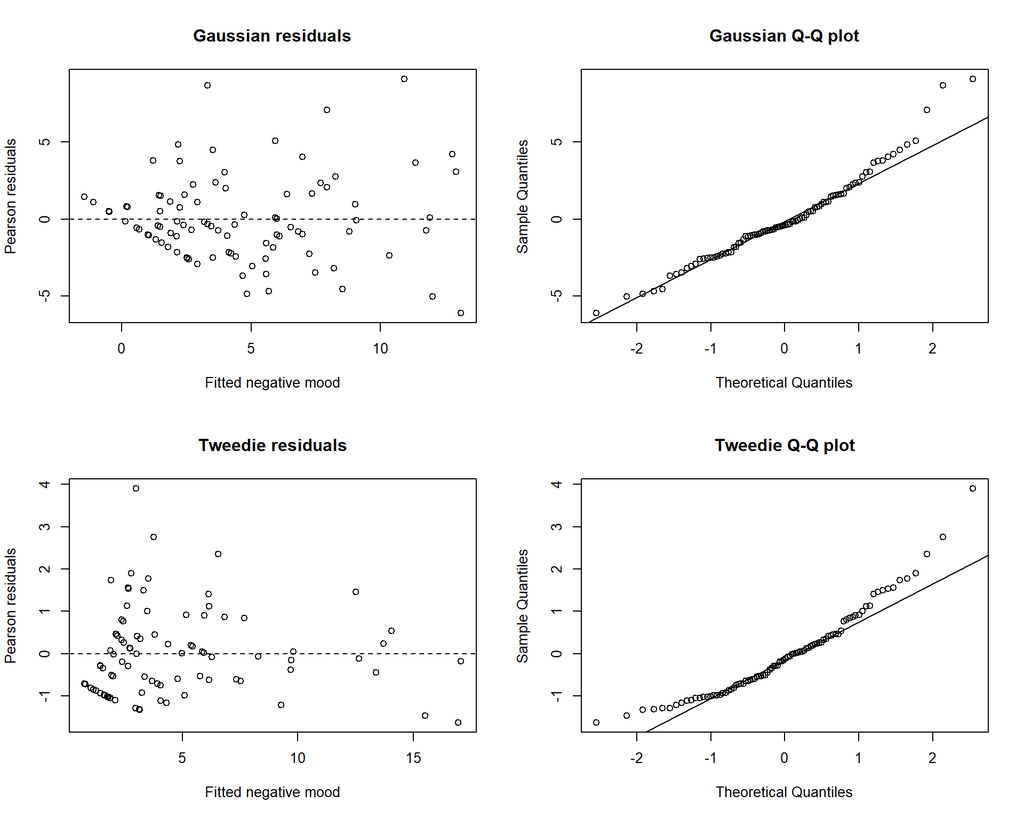

```r
family_comparison_models <- list(
  "Gaussian" = lm1.2_negative_gaussian,
  "Tweedie" = glm1.2_negative
)

par(mfrow = c(2, 2))
for (model_name in names(family_comparison_models)) {
  model <- family_comparison_models[[model_name]]
  pearson_residuals <- residuals(model, type = "pearson")
  plot(
    fitted(model), pearson_residuals,
    xlab = "Fitted negative mood", ylab = "Pearson residuals",
    main = paste(model_name, "residuals")
  )
  abline(h = 0, lty = 2)
  qqnorm(pearson_residuals, main = paste(model_name, "Q-Q plot"))
  qqline(pearson_residuals)
}
```

### Decomposing the retained interaction

The retained post-Tangram negative-mood Tweedie model was refitted with Failure and then Success as the reference condition. These refits retain the same complete-case sample, predictors, Tweedie family, and log link. The `Perf_Strivings_c` coefficient tests the Strivings slope within the reference condition: Control in the original model, Failure in the first refit, and Success in the second. Interaction coefficients test differences between condition-specific slopes. Slopes are expressed on the log scale and are interpreted separately from the supported between-condition interaction.

```r
mood_negative_cc_failure <- mood_negative_cc
mood_negative_cc_failure$Condition <- relevel(
  mood_negative_cc_failure$Condition, ref = "Failure"
)

glm1.2_negative_failure_ref <- update(
  glm1.2_negative,
  data = mood_negative_cc_failure
)
summary(glm1.2_negative_failure_ref)
```

```
##  Family: tweedie  ( log )
## Formula:
## NEG_4 ~ NEG_3 + Perf_Strivings_c * Condition + Perf_Concerns_c *
##     Condition + CESD + GAD7
## Data: mood_negative_cc_failure
##
##      AIC      BIC   logLik deviance df.resid
##    432.0    467.3   -202.0    404.0       78
##
##
## Dispersion parameter for tweedie family (): 1.58
##
## Conditional model:
##                                    Estimate Std. Error z value Pr(>|z|)
## (Intercept)                        0.571994   0.234965   2.434   0.0149 *
## NEG_3                              0.139154   0.023699   5.872 4.31e-09 ***
## Perf_Strivings_c                   0.163648   0.070727   2.314   0.0207 *
## ConditionControl                  -0.008284   0.194933  -0.042   0.9661
## ConditionSuccess                   0.001425   0.200391   0.007   0.9943
## Perf_Concerns_c                    0.092634   0.073597   1.259   0.2081
## CESD                               0.003574   0.009953   0.359   0.7196
## GAD7                               0.020749   0.018867   1.100   0.2714
## Perf_Strivings_c:ConditionControl -0.247164   0.120155  -2.057   0.0397 *
## Perf_Strivings_c:ConditionSuccess -0.328373   0.130677  -2.513   0.0120 *
## ConditionControl:Perf_Concerns_c  -0.021637   0.101239  -0.214   0.8308
## ConditionSuccess:Perf_Concerns_c   0.050881   0.111150   0.458   0.6471
## ---
## Signif. codes:  0 '***' 0.001 '**' 0.01 '*' 0.05 '.' 0.1 ' ' 1
```

```r
mood_negative_cc_success <- mood_negative_cc
mood_negative_cc_success$Condition <- relevel(
  mood_negative_cc_success$Condition, ref = "Success"
)

glm1.2_negative_success_ref <- update(
  glm1.2_negative,
  data = mood_negative_cc_success
)
summary(glm1.2_negative_success_ref)
```

```
##  Family: tweedie  ( log )
## Formula:
## NEG_4 ~ NEG_3 + Perf_Strivings_c * Condition + Perf_Concerns_c *
##     Condition + CESD + GAD7
## Data: mood_negative_cc_success
##
##      AIC      BIC   logLik deviance df.resid
##    432.0    467.3   -202.0    404.0       78
##
##
## Dispersion parameter for tweedie family (): 1.58
##
## Conditional model:
##                                    Estimate Std. Error z value Pr(>|z|)
## (Intercept)                        0.573417   0.195607   2.931  0.00337 **
## NEG_3                              0.139154   0.023699   5.872 4.31e-09 ***
## Perf_Strivings_c                  -0.164725   0.109607  -1.503  0.13287
## ConditionControl                  -0.009709   0.186649  -0.052  0.95851
## ConditionFailure                  -0.001425   0.200391  -0.007  0.99432
## Perf_Concerns_c                    0.143515   0.088577   1.620  0.10518
## CESD                               0.003574   0.009953   0.359  0.71955
## GAD7                               0.020749   0.018867   1.100  0.27143
## Perf_Strivings_c:ConditionControl  0.081207   0.148175   0.548  0.58366
## Perf_Strivings_c:ConditionFailure  0.328372   0.130677   2.513  0.01198 *
## ConditionControl:Perf_Concerns_c  -0.072517   0.112534  -0.644  0.51932
## ConditionFailure:Perf_Concerns_c  -0.050881   0.111150  -0.458  0.64712
## ---
## Signif. codes:  0 '***' 0.001 '**' 0.01 '*' 0.05 '.' 0.1 ' ' 1
```

The following table reports each condition-specific Strivings slope, its standard error, Wald 95% confidence interval, and unadjusted two-sided p value.

```r
negative_mood_reference_models <- list(
  Control = glm1.2_negative,
  Failure = glm1.2_negative_failure_ref,
  Success = glm1.2_negative_success_ref
)

stopifnot(all(vapply(negative_mood_reference_models, nobs, numeric(1)) ==
                nrow(mood_negative_cc)))

negative_mood_strivings_slopes <- do.call(
  rbind,
  lapply(names(negative_mood_reference_models), function(condition_name) {
    model <- negative_mood_reference_models[[condition_name]]
    coefficient <- summary(model)$coefficients$cond["Perf_Strivings_c", ]
    data.frame(
      Condition = condition_name,
      estimate = unname(coefficient["Estimate"]),
      SE = unname(coefficient["Std. Error"]),
      lower.CL = unname(coefficient["Estimate"] -
                         qnorm(0.975) * coefficient["Std. Error"]),
      upper.CL = unname(coefficient["Estimate"] +
                         qnorm(0.975) * coefficient["Std. Error"]),
      z = unname(coefficient["z value"]),
      p.value = unname(coefficient["Pr(>|z|)"])
    )
  })
)
negative_mood_strivings_slopes
```

```
##   Condition    estimate         SE    lower.CL   upper.CL          z    p.value
## 1   Control -0.08351598 0.09939663 -0.27832978 0.11129783 -0.8402295 0.40077973
## 2   Failure  0.16364755 0.07072746  0.02502428 0.30227082  2.3137768 0.02067997
## 3   Success -0.16472499 0.10960700 -0.37955076 0.05010079 -1.5028692 0.13287278
```

### Distributional Model Diagnostics

The following plots examine residual patterns from the best-supported nested model for each mood outcome and interval. Both positive-mood models and the post-ABM negative-mood model use the Gaussian family; the post-Tangram negative-mood model uses the Tweedie family. The full interaction model is used only when it significantly improves fit over its reduced counterpart.

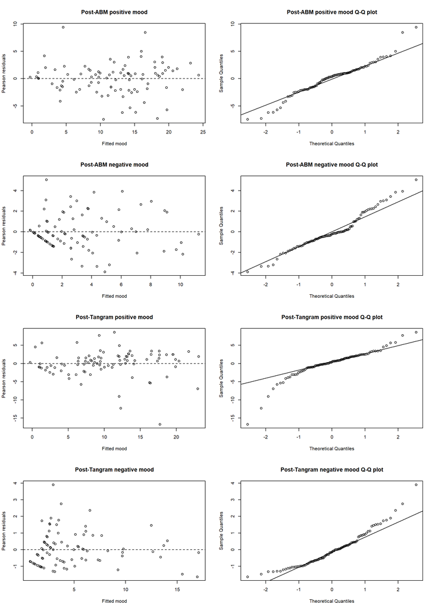

```r
select_supported_model <- function(reduced, full, alpha = .05) {
  comparison <- anova(reduced, full)
  p_column <- grep("^Pr\\(", names(comparison), value = TRUE)
  p_value <- comparison[[p_column[1]]][2]
  if (!is.na(p_value) && p_value < alpha) full else reduced
}

mood_diagnostic_models <- list(
  "Post-ABM positive mood" = select_supported_model(
    lm0.1_positive_reduced, lm0.1_positive
  ),
  "Post-ABM negative mood" = select_supported_model(
    lm0.2_negative_reduced, lm0.2_negative
  ),
  "Post-Tangram positive mood" = select_supported_model(
    lm1.1_positive_reduced, lm1.1_positive
  ),
  "Post-Tangram negative mood" = select_supported_model(
    glm1.2_negative_reduced, glm1.2_negative
  )
)

par(mfrow = c(4, 2))
for (model_name in names(mood_diagnostic_models)) {
  model <- mood_diagnostic_models[[model_name]]
  pearson_residuals <- residuals(model, type = "pearson")
  plot(
    fitted(model), pearson_residuals,
    xlab = "Fitted mood", ylab = "Pearson residuals",
    main = model_name
  )
  abline(h = 0, lty = 2)
  qqnorm(pearson_residuals, main = paste(model_name, "Q-Q plot"))
  qqline(pearson_residuals)
}
```

**Interaction plots**

Only interactions meeting both criteria–a significant omnibus model comparison and a significant individual interaction–are plotted. In the current results, this rule supports plotting the interaction of Perfectionistic Strivings with ABM condition for post-Tangram negative mood only. All lines are solid; the failure-condition line is thicker and shown at full opacity because the Strivings-by-Failure versus Control coefficient was significant, whereas the control and success lines are thinner and lighter. This visual emphasis reflects the between-condition interaction; the condition-specific Strivings slope tests are reported separately above.

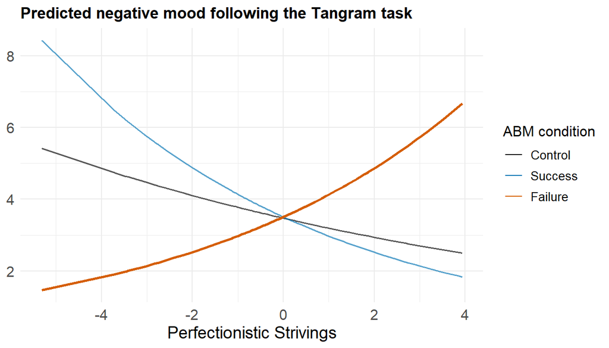

```r
pred_neg_ps <- ggpredict(
  glm1.2_negative,
  terms = c("Perf_Strivings_c [all]", "Condition"),
  type = "fixed"
)

pred_neg_ps_data <- as.data.frame(pred_neg_ps) %>%
  mutate(
    group = factor(as.character(group), levels = c("Control", "Success", "Failure")),
    supported = as.character(group) == "Failure"
  )
stopifnot(
  !anyNA(pred_neg_ps_data$group),
  setequal(as.character(unique(pred_neg_ps_data$group)),
           c("Control", "Success", "Failure"))
)

ip_neg_1 <- ggplot(
  pred_neg_ps_data,
  aes(x = x, y = predicted, group = group, color = group,
      linewidth = supported, alpha = supported)
) +
  geom_line() +
  scale_color_manual(values = c(
    Control = "#000000",
    Success = "#0072B2",
    Failure = "#D55E00"
  ), breaks = c("Control", "Success", "Failure"),
  labels = c("Control", "Success", "Failure"), drop = FALSE) +
  scale_linewidth_manual(values = c(`FALSE` = 0.65, `TRUE` = 1)
                         , guide = "none"
                         ) +
  scale_alpha_manual(values = c(`FALSE` = 0.65, `TRUE` = 1)
                     , guide = "none"
                     ) +
  labs(
    title = "Predicted negative mood following the Tangram task",
    x = "Perfectionistic Strivings",
    y = NULL,
    color = "ABM condition"
  ) +
  theme_minimal() +
  theme(
    plot.title = element_text(face = "bold"),
    legend.position = "right",
    legend.title = element_text(size = 12),
    legend.text = element_text(size = 10),
    axis.title.x = element_text(size = 14),
    axis.title.y = element_blank(),
    axis.text.x = element_text(size = 12),
    axis.text.y = element_text(size = 12)
  )

ip_neg_1
```

__________________________________________________________________

# iv) Secondary Process-Verification Analysis

This secondary analysis examined whether ABM condition moderated the category-specific association between Perfectionistic Concerns and intermediate dwell time that was supported in Study 1, remained supported after controlling for depressive and anxiety symptoms, and was also observed at T1 in the Study 2 sample. The analysis therefore provides a targeted process-verification test rather than an additional manipulation check or a conventional mediation test.

Post-ABM intermediate dwell time was modeled conditional on centered pre-ABM intermediate dwell time. The reduced model included the two-way associations among semantic category, Perfectionistic Concerns, and ABM condition, together with the same fixed covariates, random-effects structure, and dispersion submodel used in the corresponding manipulation check. The full model added the targeted three-way interaction among the negative-versus-neutral category comparison, Perfectionistic Concerns, and ABM condition.

The models were compared using a likelihood-ratio test. Because this omnibus comparison is the process-verification test, individual higher-order coefficients are not interpreted when the full model does not improve fit.

```r
process_mc_et2 <- mc_et2 %>%
  mutate(
    IA_Negative_vs_Neutral = as.numeric(IA_LABEL_f == "Negative")
  )

process_intermediate_reduced <- glmmTMB(
  dwell_time_intermediate_2_t01 ~ dwell_time_intermediate_1_c +
    IA_LABEL_f * Perf_Concerns_c + IA_LABEL_f * Condition +
    Perf_Concerns_c * Condition + block_nr_c + Change_category01 +
    # (1 | block_id) +
    (1 + Change_category01 || subject_id_2),
  REML = FALSE,
  family = beta_family(link = "logit"),
  dispformula = ~ guessed_block_rule_2,
  data = process_mc_et2,
  na.action = na.omit
)

process_intermediate_full <- update(
  process_intermediate_reduced,
  . ~ . + IA_Negative_vs_Neutral:Perf_Concerns_c:Condition
)

summary(process_intermediate_full)
```

```
##  Family: beta  ( logit )
## Formula:
## dwell_time_intermediate_2_t01 ~ dwell_time_intermediate_1_c +
##     IA_LABEL_f + Perf_Concerns_c + Condition + block_nr_c + Change_category01 +
##     (1 + Change_category01 || subject_id_2) + IA_LABEL_f:Perf_Concerns_c +
##     IA_LABEL_f:Condition + Perf_Concerns_c:Condition + Perf_Concerns_c:Condition:IA_Negative_vs_Neutral
## Dispersion:                                     ~guessed_block_rule_2
## Data: process_mc_et2
##
##      AIC      BIC   logLik deviance df.resid
## -10583.3 -10383.9   5322.6 -10645.3     4553
##
## Random effects:
##
## Conditional model:
##  Groups       Name              Variance Std.Dev. Corr
##  subject_id_2 (Intercept)       0.04046  0.2011
##               Change_category01 0.48897  0.6993   0.00
## Number of obs: 4584, groups:  subject_id_2, 92
##
## Conditional model:
##                                                           Estimate Std. Error
## (Intercept)                                             -1.6193164  0.0481957
## dwell_time_intermediate_1_c                              0.6367016  0.1083659
## IA_LABEL_fPositive                                      -0.0080973  0.0407400
## IA_LABEL_fNegative                                       0.0445055  0.0406033
## IA_LABEL_fSuccess                                       -0.0235220  0.0409566
## IA_LABEL_fFailure                                       -0.1025863  0.0413213
## Perf_Concerns_c                                         -0.0188548  0.0184584
## ConditionFailure                                        -0.1446898  0.0676349
## ConditionSuccess                                         0.0156917  0.0659432
## block_nr_c                                              -0.0031914  0.0025546
## Change_category01                                        1.0379552  0.0755823
## IA_LABEL_fPositive:Perf_Concerns_c                       0.0140456  0.0097786
## IA_LABEL_fNegative:Perf_Concerns_c                       0.0102230  0.0137232
## IA_LABEL_fSuccess:Perf_Concerns_c                       -0.0009969  0.0098017
## IA_LABEL_fFailure:Perf_Concerns_c                        0.0058212  0.0097855
## IA_LABEL_fPositive:ConditionFailure                      0.0429976  0.0579740
## IA_LABEL_fNegative:ConditionFailure                      0.0452008  0.0574005
## IA_LABEL_fSuccess:ConditionFailure                       0.0675396  0.0580204
```

[output cut: 33 more lines]

```
## IA_LABEL_fFailure:ConditionSuccess                         2.20   0.0278 *
## Perf_Concerns_c:ConditionFailure                           1.58   0.1131
## Perf_Concerns_c:ConditionSuccess                           0.57   0.5700
## Perf_Concerns_c:ConditionControl:IA_Negative_vs_Neutral    0.17   0.8612
## Perf_Concerns_c:ConditionFailure:IA_Negative_vs_Neutral   -1.44   0.1490
## Perf_Concerns_c:ConditionSuccess:IA_Negative_vs_Neutral      NA       NA
## ---
## Signif. codes:  0 '***' 0.001 '**' 0.01 '*' 0.05 '.' 0.1 ' ' 1
##
## Dispersion model:
##                      Estimate Std. Error z value Pr(>|z|)
## (Intercept)           3.43533    0.07091   48.45  < 2e-16 ***
## guessed_block_rule_2 -0.24923    0.07436   -3.35 0.000804 ***
## ---
## Signif. codes:  0 '***' 0.001 '**' 0.01 '*' 0.05 '.' 0.1 ' ' 1
```

```r
anova(process_intermediate_reduced, process_intermediate_full)
```

```
## Data: process_mc_et2
## Models:
## process_intermediate_reduced: dwell_time_intermediate_2_t01 ~ dwell_time_intermediate_1_c + , zi=~0, disp=~guessed_block_rule_2
## process_intermediate_reduced:     IA_LABEL_f * Perf_Concerns_c + IA_LABEL_f * Condition + Perf_Concerns_c * , zi=~0, disp=~guessed_block_rule_2
## process_intermediate_reduced:     Condition + block_nr_c + Change_category01 + (1 + Change_category01 || , zi=~0, disp=~guessed_block_rule_2
## process_intermediate_reduced:     subject_id_2), zi=~0, disp=~guessed_block_rule_2
## process_intermediate_full: dwell_time_intermediate_2_t01 ~ dwell_time_intermediate_1_c + , zi=~0, disp=~guessed_block_rule_2
## process_intermediate_full:     IA_LABEL_f + Perf_Concerns_c + Condition + block_nr_c + Change_category01 + , zi=~0, disp=~guessed_block_rule_2
## process_intermediate_full:     (1 + Change_category01 || subject_id_2) + IA_LABEL_f:Perf_Concerns_c + , zi=~0, disp=~guessed_block_rule_2
## process_intermediate_full:     IA_LABEL_f:Condition + Perf_Concerns_c:Condition + Perf_Concerns_c:Condition:IA_Negative_vs_Neutral, zi=~0, disp=~guessed_block_rule_2
##                              Df    AIC    BIC logLik deviance  Chisq Chi Df
## process_intermediate_reduced 29 -10584 -10398 5321.2   -10642
## process_intermediate_full    31 -10583 -10384 5322.6   -10645 2.9106      2
##                              Pr(>Chisq)
## process_intermediate_reduced
## process_intermediate_full        0.2333
```

The targeted three-way interaction did not significantly improve model fit. Accordingly, the individual higher-order coefficients were not interpreted, and this analysis did not provide evidence that ABM condition modified the negative-versus-neutral intermediate-dwell-time association with Perfectionistic Concerns.

# Reference

Brooks, M. E., Kristensen, K., van Benthem, K. J., Magnusson, A., Berg, C. W., Nielsen, A., Skaug, H. J., Mächler, M., & Bolker, B. M. (2017). glmmTMB balances speed and flexibility among packages for zero-inflated generalized linear mixed modeling. *The R Journal, 9*(2), 378–400. https://doi.org/10.32614/RJ-2017-066

Dunn, P. K., & Smyth, G. K. (2005). Series evaluation of Tweedie exponential dispersion model densities. *Statistics and Computing, 15*(4), 267–280. https://doi.org/10.1007/s11222-005-4070-y

Lo, S., & Andrews, S. (2015). To transform or not to transform: Using generalized linear mixed models to analyse reaction time data. Frontiers in Psychology, 6, Article 1171. https://doi.org/10.3389/fpsyg.2015.01171